# ANCOVA in Vocabulario Ensinado (Vocabulario Ensinado)

Geiser C. Challco geiser@alumni.usp.br

- Descriptive Statistics of Initial Data
- ANCOVA and Pairwise for one factor: **grupo**
  - Without remove non-normal data
  - Computing ANCOVA and PairWise After removing non-normal data (OK)
    - Plots for ancova
    - Checking linearity assumption
    - Checking normality and homogeneity
- ANCOVA and Pairwise for two factors **grupo:Sexo**
  - Without remove non-normal data
  - Computing ANCOVA and PairWise After removing non-normal data (OK)
    - Plots for ancova
    - Checking linearity assumption
    - Checking normality and homogeneity
- ANCOVA and Pairwise for two factors **grupo:Zona**
  - Without remove non-normal data
  - Computing ANCOVA and PairWise After removing non-normal data (OK)
    - Plots for ancova
    - Checking linearity assumption
    - Checking normality and homogeneity
- ANCOVA and Pairwise for two factors **grupo:Cor.Raca**
  - Without remove non-normal data
  - Computing ANCOVA and PairWise After removing non-normal data (OK)
    - Plots for ancova
    - Checking linearity assumption
    - Checking normality and homogeneity
- ANCOVA and Pairwise for two factors **grupo:Serie**
  - Without remove non-normal data
  - Computing ANCOVA and PairWise After removing non-normal data (OK)
    - Plots for ancova
    - Checking linearity assumption
    - Checking normality and homogeneity
- Summary of Results
  - Descriptive Statistics
  - ANCOVA Table Comparison
  - PairWise Table Comparison
  - EMMS Table Comparison

**NOTE**:

- Teste ANCOVA para determinar se houve diferenças significativas no Vocabulario Ensinado (medido usando pre- e pos-testes).
- ANCOVA test to determine whether there were significant differences in Vocabulario Ensinado (measured using pre- and post-tests).

# Descriptive Statistics of Initial Data

```r
df <- get.descriptives(dat, c(dv.pre, dv.pos), c("grupo"),
                       include.global = T, symmetry.test = T, normality.test = F)
df <- plyr::rbind.fill(
  df, do.call(plyr::rbind.fill, lapply(lfatores2, FUN = function(f) {
    if (nrow(dat) > 0 && sum(!is.na(unique(dat[[f]]))) > 1)
      get.descriptives(dat, c(dv.pre,dv.pos), c("grupo", f),
                       symmetry.test = T, normality.test = F)
    }))
)
(df <- df[,c(fatores1[fatores1 %in% colnames(df)],"variable",
             colnames(df)[!colnames(df) %in% c(fatores1,"variable")])])
```

```
##           grupo Sexo   Zona Cor.Raca Serie        variable   n  mean median min max    sd    se    ci
## 1      Controle <NA>   <NA>     <NA>  <NA> vocab.teach.pre  97 7.794    7.0   7  13 1.060 0.108 0.214
## 2  Experimental <NA>   <NA>     <NA>  <NA> vocab.teach.pre 143 7.762    7.0   7  13 1.034 0.086 0.171
## 3          <NA> <NA>   <NA>     <NA>  <NA> vocab.teach.pre 240 7.775    7.0   7  13 1.043 0.067 0.133
## 4      Controle <NA>   <NA>     <NA>  <NA> vocab.teach.pos  97 6.866    7.0   2  11 2.024 0.206 0.408
## 5  Experimental <NA>   <NA>     <NA>  <NA> vocab.teach.pos 143 7.133    7.0   1  12 2.173 0.182 0.359
## 6          <NA> <NA>   <NA>     <NA>  <NA> vocab.teach.pos 240 7.025    7.0   1  12 2.114 0.136 0.269
## 7      Controle    F   <NA>     <NA>  <NA> vocab.teach.pre  49 7.592    7.0   7  10 0.814 0.116 0.234
## 8      Controle    M   <NA>     <NA>  <NA> vocab.teach.pre  48 8.000    8.0   7  13 1.238 0.179 0.359
## 9  Experimental    F   <NA>     <NA>  <NA> vocab.teach.pre  72 7.833    7.5   7  13 1.126 0.133 0.265
## 10 Experimental    M   <NA>     <NA>  <NA> vocab.teach.pre  71 7.690    7.0   7  11 0.935 0.111 0.221
## 11     Controle    F   <NA>     <NA>  <NA> vocab.teach.pos  49 6.918    7.0   2  10 1.891 0.270 0.543
## 12     Controle    M   <NA>     <NA>  <NA> vocab.teach.pos  48 6.812    7.0   2  11 2.170 0.313 0.630
## 13 Experimental    F   <NA>     <NA>  <NA> vocab.teach.pos  72 7.514    8.0   2  11 2.076 0.245 0.488
## 14 Experimental    M   <NA>     <NA>  <NA> vocab.teach.pos  71 6.746    7.0   1  12 2.215 0.263 0.524
```

[output cut: 98 more lines]

| grupo | Sexo | Zona | Cor.Raca | Serie | variable | n | mean | median | min | max | sd | se | ci | iqr | symmetry | skewness | kurtosis |
| --- | --- | --- | --- | --- | --- | --- | --- | --- | --- | --- | --- | --- | --- | --- | --- | --- | --- |
| Controle |  |  |  |  | vocab.teach.pre | 97 | 7.794 | 7.0 | 7 | 13 | 1.060 | 0.108 | 0.214 | 1.00 | NO | 1.866 | 5.018 |
| Experimental |  |  |  |  | vocab.teach.pre | 143 | 7.762 | 7.0 | 7 | 13 | 1.034 | 0.086 | 0.171 | 1.00 | NO | 1.809 | 4.529 |
|  |  |  |  |  | vocab.teach.pre | 240 | 7.775 | 7.0 | 7 | 13 | 1.043 | 0.067 | 0.133 | 1.00 | NO | 1.846 | 4.812 |
| Controle |  |  |  |  | vocab.teach.pos | 97 | 6.866 | 7.0 | 2 | 11 | 2.024 | 0.206 | 0.408 | 2.00 | YES | -0.245 | -0.452 |
| Experimental |  |  |  |  | vocab.teach.pos | 143 | 7.133 | 7.0 | 1 | 12 | 2.173 | 0.182 | 0.359 | 3.00 | YES | -0.276 | -0.418 |
|  |  |  |  |  | vocab.teach.pos | 240 | 7.025 | 7.0 | 1 | 12 | 2.114 | 0.136 | 0.269 | 3.00 | YES | -0.252 | -0.404 |
| Controle | F |  |  |  | vocab.teach.pre | 49 | 7.592 | 7.0 | 7 | 10 | 0.814 | 0.116 | 0.234 | 1.00 | NO | 1.070 | 0.018 |
| Controle | M |  |  |  | vocab.teach.pre | 48 | 8.000 | 8.0 | 7 | 13 | 1.238 | 0.179 | 0.359 | 1.00 | NO | 1.780 | 3.924 |
| Experimental | F |  |  |  | vocab.teach.pre | 72 | 7.833 | 7.5 | 7 | 13 | 1.126 | 0.133 | 0.265 | 1.00 | NO | 1.901 | 4.910 |
| Experimental | M |  |  |  | vocab.teach.pre | 71 | 7.690 | 7.0 | 7 | 11 | 0.935 | 0.111 | 0.221 | 1.00 | NO | 1.465 | 2.189 |
| Controle | F |  |  |  | vocab.teach.pos | 49 | 6.918 | 7.0 | 2 | 10 | 1.891 | 0.270 | 0.543 | 2.00 | YES | -0.139 | -0.616 |
| Controle | M |  |  |  | vocab.teach.pos | 48 | 6.812 | 7.0 | 2 | 11 | 2.170 | 0.313 | 0.630 | 2.25 | YES | -0.290 | -0.533 |
| Experimental | F |  |  |  | vocab.teach.pos | 72 | 7.514 | 8.0 | 2 | 11 | 2.076 | 0.245 | 0.488 | 3.00 | YES | -0.392 | -0.402 |
| Experimental | M |  |  |  | vocab.teach.pos | 71 | 6.746 | 7.0 | 1 | 12 | 2.215 | 0.263 | 0.524 | 3.00 | YES | -0.134 | -0.422 |
| Controle |  | Rural |  |  | vocab.teach.pre | 46 | 7.630 | 7.0 | 7 | 11 | 0.951 | 0.140 | 0.282 | 1.00 | NO | 1.527 | 1.943 |
| Controle |  | Urbana |  |  | vocab.teach.pre | 18 | 7.611 | 7.0 | 7 | 10 | 0.979 | 0.231 | 0.487 | 1.00 | few data | 0.000 | 0.000 |
| Controle |  |  |  |  | vocab.teach.pre | 33 | 8.121 | 8.0 | 7 | 13 | 1.193 | 0.208 | 0.423 | 2.00 | NO | 2.026 | 5.972 |
| Experimental |  | Rural |  |  | vocab.teach.pre | 61 | 7.689 | 7.0 | 7 | 11 | 0.975 | 0.125 | 0.250 | 1.00 | NO | 1.487 | 2.037 |
| Experimental |  | Urbana |  |  | vocab.teach.pre | 40 | 7.950 | 8.0 | 7 | 13 | 1.239 | 0.196 | 0.396 | 1.00 | NO | 2.062 | 5.208 |
| Experimental |  |  |  |  | vocab.teach.pre | 42 | 7.690 | 7.0 | 7 | 10 | 0.897 | 0.138 | 0.279 | 1.00 | NO | 1.019 | -0.060 |
| Controle |  | Rural |  |  | vocab.teach.pos | 46 | 7.043 | 7.0 | 2 | 10 | 2.022 | 0.298 | 0.600 | 2.75 | NO | -0.516 | -0.236 |
| Controle |  | Urbana |  |  | vocab.teach.pos | 18 | 6.611 | 6.0 | 5 | 10 | 1.501 | 0.354 | 0.746 | 1.00 | NO | 0.834 | -0.493 |
| Controle |  |  |  |  | vocab.teach.pos | 33 | 6.758 | 7.0 | 2 | 11 | 2.292 | 0.399 | 0.813 | 3.00 | YES | -0.164 | -0.918 |
| Experimental |  | Rural |  |  | vocab.teach.pos | 61 | 7.295 | 7.0 | 3 | 12 | 2.246 | 0.288 | 0.575 | 4.00 | YES | -0.086 | -0.895 |
| Experimental |  | Urbana |  |  | vocab.teach.pos | 40 | 7.250 | 7.0 | 3 | 11 | 2.085 | 0.330 | 0.667 | 2.25 | YES | -0.325 | -0.446 |
| Experimental |  |  |  |  | vocab.teach.pos | 42 | 6.786 | 7.0 | 1 | 10 | 2.159 | 0.333 | 0.673 | 2.75 | NO | -0.553 | -0.145 |
| Controle |  |  | Branca |  | vocab.teach.pre | 9 | 8.000 | 7.0 | 7 | 11 | 1.414 | 0.471 | 1.087 | 2.00 | NO | 0.943 | -0.556 |
| Controle |  |  | Indígena |  | vocab.teach.pre | 2 | 7.000 | 7.0 | 7 | 7 | 0.000 | 0.000 | 0.000 | 0.00 | few data | 0.000 | 0.000 |
| Controle |  |  | Parda |  | vocab.teach.pre | 29 | 7.828 | 7.0 | 7 | 13 | 1.391 | 0.258 | 0.529 | 1.00 | NO | 1.990 | 4.161 |
| Controle |  |  |  |  | vocab.teach.pre | 57 | 7.772 | 8.0 | 7 | 10 | 0.802 | 0.106 | 0.213 | 1.00 | NO | 0.827 | 0.127 |
| Experimental |  |  | Branca |  | vocab.teach.pre | 14 | 7.357 | 7.0 | 7 | 8 | 0.497 | 0.133 | 0.287 | 1.00 | few data | 0.000 | 0.000 |
| Experimental |  |  | Indígena |  | vocab.teach.pre | 1 | 7.000 | 7.0 | 7 | 7 |  |  |  | 0.00 | few data | 0.000 | 0.000 |
| Experimental |  |  | Parda |  | vocab.teach.pre | 34 | 7.882 | 8.0 | 7 | 10 | 0.913 | 0.157 | 0.319 | 2.00 | YES | 0.454 | -1.172 |
| Experimental |  |  |  |  | vocab.teach.pre | 94 | 7.787 | 7.0 | 7 | 13 | 1.125 | 0.116 | 0.230 | 1.00 | NO | 1.942 | 4.640 |
| Controle |  |  | Branca |  | vocab.teach.pos | 9 | 7.222 | 8.0 | 4 | 11 | 2.333 | 0.778 | 1.794 | 4.00 | YES | 0.078 | -1.564 |
| Controle |  |  | Indígena |  | vocab.teach.pos | 2 | 8.000 | 8.0 | 8 | 8 | 0.000 | 0.000 | 0.000 | 0.00 | few data | 0.000 | 0.000 |
| Controle |  |  | Parda |  | vocab.teach.pos | 29 | 6.931 | 7.0 | 2 | 10 | 2.103 | 0.391 | 0.800 | 3.00 | YES | -0.246 | -0.642 |
| Controle |  |  |  |  | vocab.teach.pos | 57 | 6.737 | 7.0 | 2 | 10 | 1.987 | 0.263 | 0.527 | 2.00 | YES | -0.285 | -0.407 |
| Experimental |  |  | Branca |  | vocab.teach.pos | 14 | 7.286 | 7.0 | 4 | 10 | 1.816 | 0.485 | 1.048 | 2.75 | YES | -0.037 | -1.170 |
| Experimental |  |  | Indígena |  | vocab.teach.pos | 1 | 8.000 | 8.0 | 8 | 8 |  |  |  | 0.00 | few data | 0.000 | 0.000 |
| Experimental |  |  | Parda |  | vocab.teach.pos | 34 | 7.235 | 8.0 | 1 | 12 | 2.618 | 0.449 | 0.913 | 4.00 | YES | -0.318 | -0.678 |
| Experimental |  |  |  |  | vocab.teach.pos | 94 | 7.064 | 7.0 | 2 | 11 | 2.073 | 0.214 | 0.425 | 2.00 | YES | -0.256 | -0.559 |
| Controle |  |  |  | 6 ano | vocab.teach.pre | 13 | 7.692 | 7.0 | 7 | 10 | 0.947 | 0.263 | 0.572 | 1.00 | NO | 1.115 | 0.145 |
| Controle |  |  |  | 7 ano | vocab.teach.pre | 16 | 7.812 | 7.0 | 7 | 11 | 1.167 | 0.292 | 0.622 | 1.25 | NO | 1.281 | 0.808 |
| Controle |  |  |  | 8 ano | vocab.teach.pre | 24 | 7.583 | 7.0 | 7 | 10 | 0.881 | 0.180 | 0.372 | 1.00 | NO | 1.222 | 0.332 |
| Controle |  |  |  | 9 ano | vocab.teach.pre | 44 | 7.932 | 8.0 | 7 | 13 | 1.149 | 0.173 | 0.349 | 1.00 | NO | 2.106 | 6.351 |
| Experimental |  |  |  | 6 ano | vocab.teach.pre | 19 | 7.842 | 7.0 | 7 | 11 | 1.214 | 0.279 | 0.585 | 1.50 | NO | 1.166 | 0.200 |
| Experimental |  |  |  | 7 ano | vocab.teach.pre | 41 | 7.902 | 7.0 | 7 | 13 | 1.281 | 0.200 | 0.404 | 1.00 | NO | 1.919 | 4.350 |
| Experimental |  |  |  | 8 ano | vocab.teach.pre | 37 | 7.622 | 7.0 | 7 | 9 | 0.794 | 0.131 | 0.265 | 1.00 | few data | 0.000 | 0.000 |
| Experimental |  |  |  | 9 ano | vocab.teach.pre | 46 | 7.717 | 8.0 | 7 | 11 | 0.886 | 0.131 | 0.263 | 1.00 | NO | 1.500 | 2.645 |
| Controle |  |  |  | 6 ano | vocab.teach.pos | 13 | 5.769 | 6.0 | 2 | 9 | 1.922 | 0.533 | 1.161 | 3.00 | YES | -0.219 | -0.900 |
| Controle |  |  |  | 7 ano | vocab.teach.pos | 16 | 6.500 | 6.0 | 2 | 10 | 1.932 | 0.483 | 1.030 | 1.50 | YES | -0.208 | -0.045 |
| Controle |  |  |  | 8 ano | vocab.teach.pos | 24 | 7.000 | 8.0 | 2 | 10 | 1.978 | 0.404 | 0.835 | 2.25 | NO | -0.743 | -0.306 |
| Controle |  |  |  | 9 ano | vocab.teach.pos | 44 | 7.250 | 7.0 | 3 | 11 | 2.036 | 0.307 | 0.619 | 3.00 | YES | -0.090 | -0.916 |
| Experimental |  |  |  | 6 ano | vocab.teach.pos | 19 | 7.105 | 7.0 | 3 | 10 | 2.079 | 0.477 | 1.002 | 2.50 | YES | -0.097 | -0.983 |
| Experimental |  |  |  | 7 ano | vocab.teach.pos | 41 | 6.512 | 6.0 | 2 | 11 | 2.491 | 0.389 | 0.786 | 3.00 | YES | 0.085 | -1.088 |
| Experimental |  |  |  | 8 ano | vocab.teach.pos | 37 | 7.081 | 7.0 | 3 | 11 | 2.019 | 0.332 | 0.673 | 3.00 | YES | -0.029 | -0.814 |
| Experimental |  |  |  | 9 ano | vocab.teach.pos | 46 | 7.739 | 8.0 | 1 | 12 | 1.914 | 0.282 | 0.568 | 2.00 | NO | -0.751 | 1.729 |

# ANCOVA and Pairwise for one factor: **grupo**

## Without remove non-normal data

```r
pdat = remove_group_data(dat[!is.na(dat[["grupo"]]),], "vocab.teach.pos", "grupo")

pdat.long <- rbind(pdat[,c("id","grupo")], pdat[,c("id","grupo")])
pdat.long[["time"]] <- c(rep("pre", nrow(pdat)), rep("pos", nrow(pdat)))
pdat.long[["time"]] <- factor(pdat.long[["time"]], c("pre","pos"))
pdat.long[["vocab.teach"]] <- c(pdat[["vocab.teach.pre"]], pdat[["vocab.teach.pos"]])

aov = anova_test(pdat, vocab.teach.pos ~ vocab.teach.pre + grupo)
laov[["grupo"]] <- get_anova_table(aov)
```

```r
pwc <- emmeans_test(pdat, vocab.teach.pos ~ grupo, covariate = vocab.teach.pre,
                    p.adjust.method = "bonferroni")
```

```r
pwc.long <- emmeans_test(dplyr::group_by_at(pdat.long, "grupo"),
                          vocab.teach ~ time,
                          p.adjust.method = "bonferroni")
lpwc[["grupo"]] <- plyr::rbind.fill(pwc, pwc.long)
```

```r
ds <- get.descriptives(pdat, "vocab.teach.pos", "grupo", covar = "vocab.teach.pre")
ds <- merge(ds[ds$variable != "vocab.teach.pre",],
            ds[ds$variable == "vocab.teach.pre", !colnames(ds) %in% c("variable")],
            by = "grupo", all.x = T, suffixes = c("", ".vocab.teach.pre"))
ds <- merge(get_emmeans(pwc), ds, by = "grupo", suffixes = c(".emms", ""))
ds <- ds[,c("grupo","n","mean.vocab.teach.pre","se.vocab.teach.pre","mean","se","emmean","se.emms")]

colnames(ds) <- c("grupo", "N", paste0(c("M","SE")," (pre)"),
                  paste0(c("M","SE"), " (unadj)"), paste0(c("M", "SE"), " (adj)"))

lemms[["grupo"]] <- ds
```

## Computing ANCOVA and PairWise After removing non-normal data (OK)

```r
wdat = pdat

res = residuals(lm(vocab.teach.pos ~ vocab.teach.pre + grupo, data = wdat))
non.normal = getNonNormal(res, wdat$id, plimit = 0.05)

wdat = wdat[!wdat$id %in% non.normal,]

wdat.long <- rbind(wdat[,c("id","grupo")], wdat[,c("id","grupo")])
wdat.long[["time"]] <- c(rep("pre", nrow(wdat)), rep("pos", nrow(wdat)))
wdat.long[["time"]] <- factor(wdat.long[["time"]], c("pre","pos"))
wdat.long[["vocab.teach"]] <- c(wdat[["vocab.teach.pre"]], wdat[["vocab.teach.pos"]])

ldat[["grupo"]] = wdat

(non.normal)
```

```
##   [1] "P2152" "P3688" "P1846" "P588"  "P1133" "P3718" "P3245" "P3720" "P3719" "P3657" "P1650" "P2845"
##  [13] "P3728" "P1854" "P2481" "P1772" "P1116" "P596"  "P3733" "P3608" "P2084" "P3710" "P1707" "P3157"
##  [25] "P1888" "P3242" "P3704" "P3088" "P2480" "P2463" "P600"  "P2200" "P2412" "P2951" "P2476" "P3531"
##  [37] "P2079" "P846"  "P3284" "P552"  "P3534" "P1985" "P3712" "P938"  "P1153" "P2113" "P2295" "P3669"
##  [49] "P3693" "P3283" "P3643" "P2961" "P3595" "P3730" "P2381" "P633"  "P3151" "P3574" "P3620" "P3715"
##  [61] "P3599" "P2370" "P1060" "P2469" "P3259" "P3144" "P2127" "P3264" "P1778" "P2452" "P859"  "P548"
##  [73] "P2368" "P559"  "P2353" "P3699" "P2139" "P2360" "P2432" "P3301" "P3652" "P1113" "P851"  "P2150"
##  [85] "P2387" "P2393" "P3171" "P2225" "P3241" "P3079" "P914"  "P3268" "P2066" "P2117" "P2123" "P2459"
##  [97] "P1949" "P2948" "P2410" "P1053" "P518"  "P2301" "P980"  "P3621" "P1001" "P526"  "P918"  "P1968"
## [109] "P2170" "P3149" "P496"  "P2445" "P1603" "P3703" "P2338" "P844"  "P2883" "P1028" "P2074" "P2175"
## [121] "P3528" "P2361" "P2088" "P2306" "P999"  "P2322" "P2379" "P1665" "P828"  "P2299" "P467"  "P2475"
## [133] "P2070" "P3550" "P2065" "P2873" "P2350" "P2446" "P1876" "P1709" "P1712" "P3226" "P3247" "P1147"
## [145] "P2108" "P2312" "P2990" "P3614" "P1900" "P3024" "P3523" "P2367" "P2461" "P916"  "P3138" "P2428"
## [157] "P3076" "P2196" "P2363" "P1596" "P499"  "P1833" "P3666" "P3676" "P3647" "P1851" "P3499" "P3714"
## [169] "P2323" "P2399" "P1085" "P2984" "P2309" "P3568" "P536"  "P2354" "P925"  "P1033" "P2357" "P3221"
## [181] "P1013" "P2296" "P2997" "P1076" "P3095" "P3603" "P3218" "P1679" "P3021" "P2331" "P2206" "P1136"
## [193] "P3663" "P907"  "P3551" "P3538" "P494"
```

```r
aov = anova_test(wdat, vocab.teach.pos ~ vocab.teach.pre + grupo)
laov[["grupo"]] <- merge(get_anova_table(aov), laov[["grupo"]], by="Effect", suffixes = c("","'"))

(df = get_anova_table(aov))
```

```
## ANOVA Table (type II tests)
##
##            Effect DFn DFd      F        p p<.05   ges
## 1 vocab.teach.pre   1  40 19.726 6.88e-05     * 0.330
## 2           grupo   1  40  4.409 4.20e-02     * 0.099
```

| Effect | DFn | DFd | F | p | p<.05 | ges |
| --- | --- | --- | --- | --- | --- | --- |
| vocab.teach.pre | 1 | 40 | 19.726 | 0.000 | * | 0.330 |
| grupo | 1 | 40 | 4.409 | 0.042 | * | 0.099 |

| term | .y. | group1 | group2 | df | statistic | p | p.adj | p.adj.signif |
| --- | --- | --- | --- | --- | --- | --- | --- | --- |
| vocab.teach.pre*grupo | vocab.teach.pos | Controle | Experimental | 40 | -2.1 | 0.042 | 0.042 | * |

```r
pwc.long <- emmeans_test(dplyr::group_by_at(wdat.long, "grupo"),
                         vocab.teach ~ time,
                         p.adjust.method = "bonferroni")
lpwc[["grupo"]] <- merge(plyr::rbind.fill(pwc, pwc.long), lpwc[["grupo"]], by=c("grupo","term",".y.","group1","group2"), suffixes = c("","'"))
```

| grupo | term | .y. | group1 | group2 | df | statistic | p | p.adj | p.adj.signif |
| --- | --- | --- | --- | --- | --- | --- | --- | --- | --- |
| Controle | time | vocab.teach | pre | pos | 82 | 8.668 | 0 | 0 | **** |
| Experimental | time | vocab.teach | pre | pos | 82 | 10.268 | 0 | 0 | **** |

```r
ds <- get.descriptives(wdat, "vocab.teach.pos", "grupo", covar = "vocab.teach.pre")
ds <- merge(ds[ds$variable != "vocab.teach.pre",],
            ds[ds$variable == "vocab.teach.pre", !colnames(ds) %in% c("variable")],
            by = "grupo", all.x = T, suffixes = c("", ".vocab.teach.pre"))
ds <- merge(get_emmeans(pwc), ds, by = "grupo", suffixes = c(".emms", ""))
ds <- ds[,c("grupo","n","mean.vocab.teach.pre","se.vocab.teach.pre","mean","se","emmean","se.emms")]

colnames(ds) <- c("grupo", "N", paste0(c("M","SE")," (pre)"),
                  paste0(c("M","SE"), " (unadj)"), paste0(c("M", "SE"), " (adj)"))

lemms[["grupo"]] <- merge(ds, lemms[["grupo"]], by=c("grupo"), suffixes = c("","'"))
```

| grupo | N | M (pre) | SE (pre) | M (unadj) | SE (unadj) | M (adj) | SE (adj) |
| --- | --- | --- | --- | --- | --- | --- | --- |
| Controle | 14 | 8.071 | 0.425 | 3.714 | 0.322 | 3.651 | 0.256 |
| Experimental | 29 | 7.862 | 0.266 | 4.276 | 0.210 | 4.306 | 0.178 |

### Plots for ancova

```r
plots <- oneWayAncovaPlots(
  wdat, "vocab.teach.pos", "grupo", aov, list("grupo"=pwc), addParam = c("mean_se"),
  font.label.size=10, step.increase=0.05, p.label="p.adj",
  subtitle = which(aov$Effect == "grupo"))
```

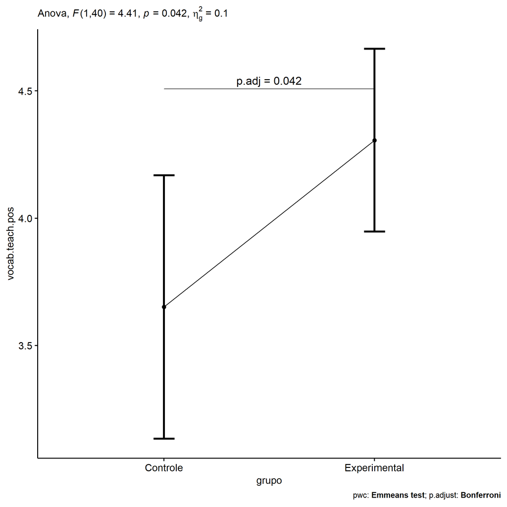

```r
if (!is.null(nrow(plots[["grupo"]]$data)))
  plots[["grupo"]] + ggplot2::scale_color_manual(values = color[["grupo"]])
```

```r
plots <- oneWayAncovaBoxPlots(
  wdat, "vocab.teach.pos", "grupo", aov, pwc, covar = "vocab.teach.pre",
  theme = "classic", color = color[["grupo"]],
  subtitle = which(aov$Effect == "grupo"))
```

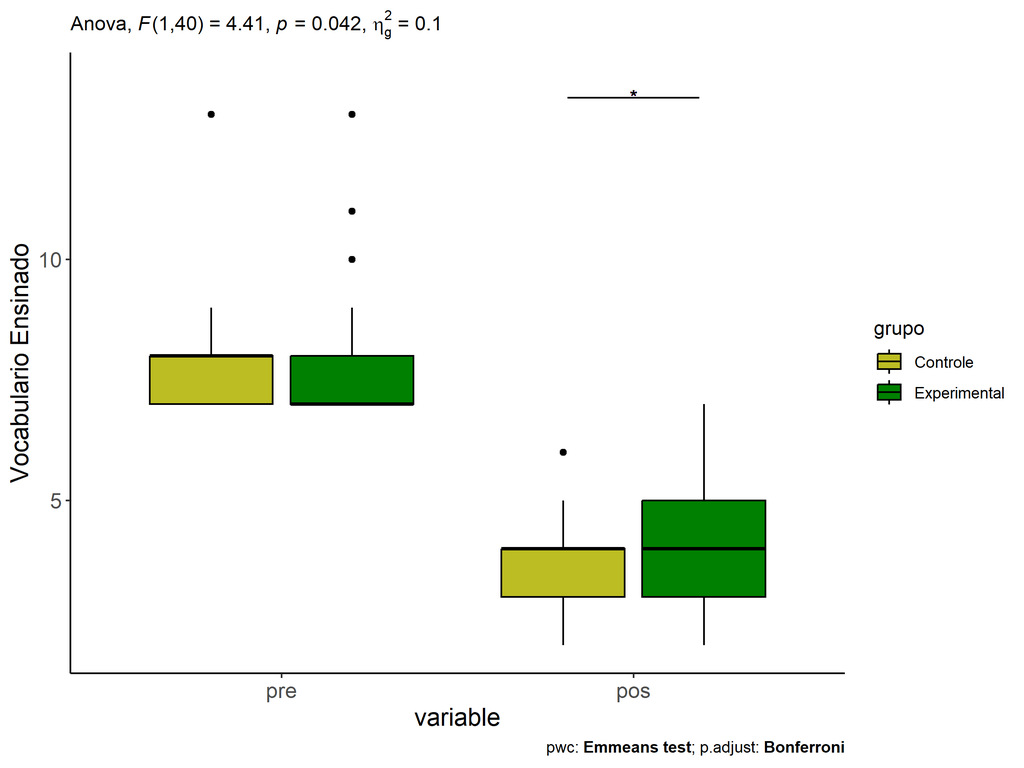

```r
if (length(unique(wdat[["grupo"]])) > 1)
  plots[["grupo"]] + ggplot2::ylab("Vocabulario Ensinado") + ggplot2::scale_x_discrete(labels=c('pre', 'pos'))
```

```r
if (length(unique(wdat.long[["grupo"]])) > 1)
  plots <- oneWayAncovaBoxPlots(
    wdat.long, "vocab.teach", "grupo", aov, pwc.long, pre.post = "time",
    theme = "classic", color = color$prepost)
```

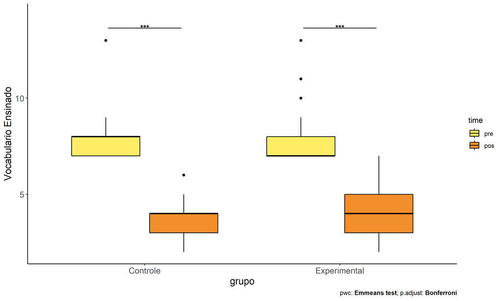

```r
if (length(unique(wdat.long[["grupo"]])) > 1)
  plots[["grupo"]] + ggplot2::ylab("Vocabulario Ensinado")
```

### Checking linearity assumption

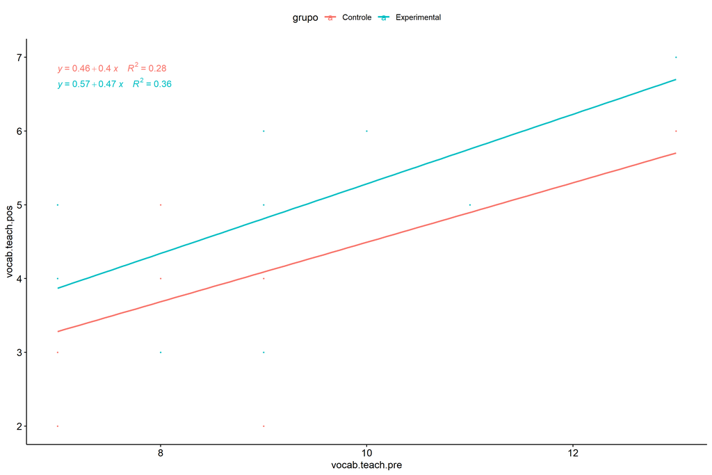

```r
ggscatter(wdat, x = "vocab.teach.pre", y = "vocab.teach.pos", size = 0.5,
          color = "grupo", add = "reg.line")+
  stat_regline_equation(
    aes(label =  paste(..eq.label.., ..rr.label.., sep = "~~~~"), color = grupo)
  )
```

### Checking normality and homogeneity

```r
res <- augment(lm(vocab.teach.pos ~ vocab.teach.pre + grupo, data = wdat))
```

```r
shapiro_test(res$.resid)
```

```
## # A tibble: 1 × 3
##   variable   statistic p.value
##   <chr>          <dbl>   <dbl>
## 1 res$.resid     0.945  0.0393
```

```r
levene_test(res, .resid ~ grupo)
```

```
## # A tibble: 1 × 4
##     df1   df2 statistic     p
##   <int> <int>     <dbl> <dbl>
## 1     1    41     0.160 0.691
```

# ANCOVA and Pairwise for two factors **grupo:Sexo**

## Without remove non-normal data

```r
pdat = remove_group_data(dat[!is.na(dat[["grupo"]]) & !is.na(dat[["Sexo"]]),], "vocab.teach.pos", c("grupo","Sexo"))

pdat.long <- rbind(pdat[,c("id","grupo","Sexo")], pdat[,c("id","grupo","Sexo")])
pdat.long[["time"]] <- c(rep("pre", nrow(pdat)), rep("pos", nrow(pdat)))
pdat.long[["time"]] <- factor(pdat.long[["time"]], c("pre","pos"))
pdat.long[["vocab.teach"]] <- c(pdat[["vocab.teach.pre"]], pdat[["vocab.teach.pos"]])

aov = anova_test(pdat, vocab.teach.pos ~ vocab.teach.pre + grupo*Sexo)
laov[["grupo:Sexo"]] <- get_anova_table(aov)
```

```r
pwcs <- list()
pwcs[["Sexo"]] <- emmeans_test(
  group_by(pdat, grupo), vocab.teach.pos ~ Sexo,
  covariate = vocab.teach.pre, p.adjust.method = "bonferroni")
pwcs[["grupo"]] <- emmeans_test(
  group_by(pdat, Sexo), vocab.teach.pos ~ grupo,
  covariate = vocab.teach.pre, p.adjust.method = "bonferroni")

pwc <- plyr::rbind.fill(pwcs[["grupo"]], pwcs[["Sexo"]])
pwc <- pwc[,c("grupo","Sexo", colnames(pwc)[!colnames(pwc) %in% c("grupo","Sexo")])]
```

```r
pwc.long <- emmeans_test(dplyr::group_by_at(pdat.long, c("grupo","Sexo")),
                         vocab.teach ~ time,
                         p.adjust.method = "bonferroni")
lpwc[["grupo:Sexo"]] <- plyr::rbind.fill(pwc, pwc.long)
```

```r
ds <- get.descriptives(pdat, "vocab.teach.pos", c("grupo","Sexo"), covar = "vocab.teach.pre")
ds <- merge(ds[ds$variable != "vocab.teach.pre",],
            ds[ds$variable == "vocab.teach.pre", !colnames(ds) %in% c("variable")],
            by = c("grupo","Sexo"), all.x = T, suffixes = c("", ".vocab.teach.pre"))
ds <- merge(get_emmeans(pwcs[["grupo"]]), ds, by = c("grupo","Sexo"), suffixes = c(".emms", ""))
ds <- ds[,c("grupo","Sexo","n","mean.vocab.teach.pre","se.vocab.teach.pre","mean","se","emmean","se.emms")]

colnames(ds) <- c("grupo","Sexo", "N", paste0(c("M","SE")," (pre)"),
                  paste0(c("M","SE"), " (unadj)"), paste0(c("M", "SE"), " (adj)"))

lemms[["grupo:Sexo"]] <- ds
```

## Computing ANCOVA and PairWise After removing non-normal data (OK)

```r
wdat = pdat

res = residuals(lm(vocab.teach.pos ~ vocab.teach.pre + grupo*Sexo, data = wdat))
non.normal = getNonNormal(res, wdat$id, plimit = 0.05)

wdat = wdat[!wdat$id %in% non.normal,]

wdat.long <- rbind(wdat[,c("id","grupo","Sexo")], wdat[,c("id","grupo","Sexo")])
wdat.long[["time"]] <- c(rep("pre", nrow(wdat)), rep("pos", nrow(wdat)))
wdat.long[["time"]] <- factor(wdat.long[["time"]], c("pre","pos"))
wdat.long[["vocab.teach"]] <- c(wdat[["vocab.teach.pre"]], wdat[["vocab.teach.pos"]])


ldat[["grupo:Sexo"]] = wdat

(non.normal)
```

```r
aov = anova_test(wdat, vocab.teach.pos ~ vocab.teach.pre + grupo*Sexo)
laov[["grupo:Sexo"]] <- merge(get_anova_table(aov), laov[["grupo:Sexo"]], by="Effect", suffixes = c("","'"))

(df = get_anova_table(aov))
```

```
## ANOVA Table (type II tests)
##
##            Effect DFn DFd      F        p p<.05   ges
## 1 vocab.teach.pre   1 235 17.011 5.16e-05     * 0.068
## 2           grupo   1 235  1.133 2.88e-01       0.005
## 3            Sexo   1 235  4.267 4.00e-02     * 0.018
## 4      grupo:Sexo   1 235  0.475 4.91e-01       0.002
```

| Effect | DFn | DFd | F | p | p<.05 | ges |
| --- | --- | --- | --- | --- | --- | --- |
| vocab.teach.pre | 1 | 235 | 17.011 | 0.000 | * | 0.068 |
| grupo | 1 | 235 | 1.133 | 0.288 |  | 0.005 |
| Sexo | 1 | 235 | 4.267 | 0.040 | * | 0.018 |
| grupo:Sexo | 1 | 235 | 0.475 | 0.491 |  | 0.002 |

```r
pwcs <- list()
pwcs[["Sexo"]] <- emmeans_test(
  group_by(wdat, grupo), vocab.teach.pos ~ Sexo,
  covariate = vocab.teach.pre, p.adjust.method = "bonferroni")
pwcs[["grupo"]] <- emmeans_test(
  group_by(wdat, Sexo), vocab.teach.pos ~ grupo,
  covariate = vocab.teach.pre, p.adjust.method = "bonferroni")

pwc <- plyr::rbind.fill(pwcs[["grupo"]], pwcs[["Sexo"]])
pwc <- pwc[,c("grupo","Sexo", colnames(pwc)[!colnames(pwc) %in% c("grupo","Sexo")])]
```

| grupo | Sexo | term | .y. | group1 | group2 | df | statistic | p | p.adj | p.adj.signif |
| --- | --- | --- | --- | --- | --- | --- | --- | --- | --- | --- |
|  | F | vocab.teach.pre*grupo | vocab.teach.pos | Controle | Experimental | 235 | -1.240 | 0.216 | 0.216 | ns |
|  | M | vocab.teach.pre*grupo | vocab.teach.pos | Controle | Experimental | 235 | -0.253 | 0.800 | 0.800 | ns |
| Controle |  | vocab.teach.pre*Sexo | vocab.teach.pos | F | M | 235 | 0.769 | 0.442 | 0.442 | ns |
| Experimental |  | vocab.teach.pre*Sexo | vocab.teach.pos | F | M | 235 | 2.032 | 0.043 | 0.043 | * |

```r
pwc.long <- emmeans_test(dplyr::group_by_at(wdat.long, c("grupo","Sexo")),
                         vocab.teach ~ time,
                         p.adjust.method = "bonferroni")
lpwc[["grupo:Sexo"]] <- merge(plyr::rbind.fill(pwc, pwc.long), lpwc[["grupo:Sexo"]], by=c("grupo","Sexo","term",".y.","group1","group2"), suffixes = c("","'"))
```

| grupo | Sexo | term | .y. | group1 | group2 | df | statistic | p | p.adj | p.adj.signif |
| --- | --- | --- | --- | --- | --- | --- | --- | --- | --- | --- |
| Controle | F | time | vocab.teach | pre | pos | 472 | 2.011 | 0.045 | 0.045 | * |
| Controle | M | time | vocab.teach | pre | pos | 472 | 3.509 | 0.000 | 0.000 | *** |
| Experimental | F | time | vocab.teach | pre | pos | 472 | 1.156 | 0.248 | 0.248 | ns |
| Experimental | M | time | vocab.teach | pre | pos | 472 | 3.391 | 0.001 | 0.001 | *** |

```r
ds <- get.descriptives(wdat, "vocab.teach.pos", c("grupo","Sexo"), covar = "vocab.teach.pre")
ds <- merge(ds[ds$variable != "vocab.teach.pre",],
            ds[ds$variable == "vocab.teach.pre", !colnames(ds) %in% c("variable")],
            by = c("grupo","Sexo"), all.x = T, suffixes = c("", ".vocab.teach.pre"))
ds <- merge(get_emmeans(pwcs[["grupo"]]), ds, by = c("grupo","Sexo"), suffixes = c(".emms", ""))
ds <- ds[,c("grupo","Sexo","n","mean.vocab.teach.pre","se.vocab.teach.pre","mean","se","emmean","se.emms")]

colnames(ds) <- c("grupo","Sexo", "N", paste0(c("M","SE")," (pre)"),
                  paste0(c("M","SE"), " (unadj)"), paste0(c("M", "SE"), " (adj)"))

lemms[["grupo:Sexo"]] <- merge(ds, lemms[["grupo:Sexo"]], by=c("grupo","Sexo"), suffixes = c("","'"))
```

| grupo | Sexo | N | M (pre) | SE (pre) | M (unadj) | SE (unadj) | M (adj) | SE (adj) |
| --- | --- | --- | --- | --- | --- | --- | --- | --- |
| Controle | F | 49 | 7.592 | 0.116 | 6.918 | 0.270 | 7.015 | 0.291 |
| Controle | M | 48 | 8.000 | 0.179 | 6.812 | 0.313 | 6.694 | 0.295 |
| Experimental | F | 72 | 7.833 | 0.133 | 7.514 | 0.245 | 7.483 | 0.240 |
| Experimental | M | 71 | 7.690 | 0.111 | 6.746 | 0.263 | 6.791 | 0.242 |

### Plots for ancova

```r
plots <- twoWayAncovaPlots(
  wdat, "vocab.teach.pos", c("grupo","Sexo"), aov, pwcs, addParam = c("mean_se"),
  font.label.size=10, step.increase=0.05, p.label="p.adj",
  subtitle = which(aov$Effect == "grupo:Sexo"))
```

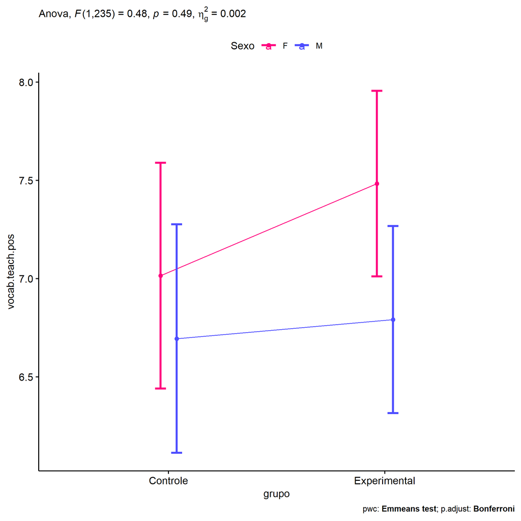

```r
if (!is.null(plots[["grupo"]]))
  plots[["grupo"]] + ggplot2::scale_color_manual(values = color[["Sexo"]])
```

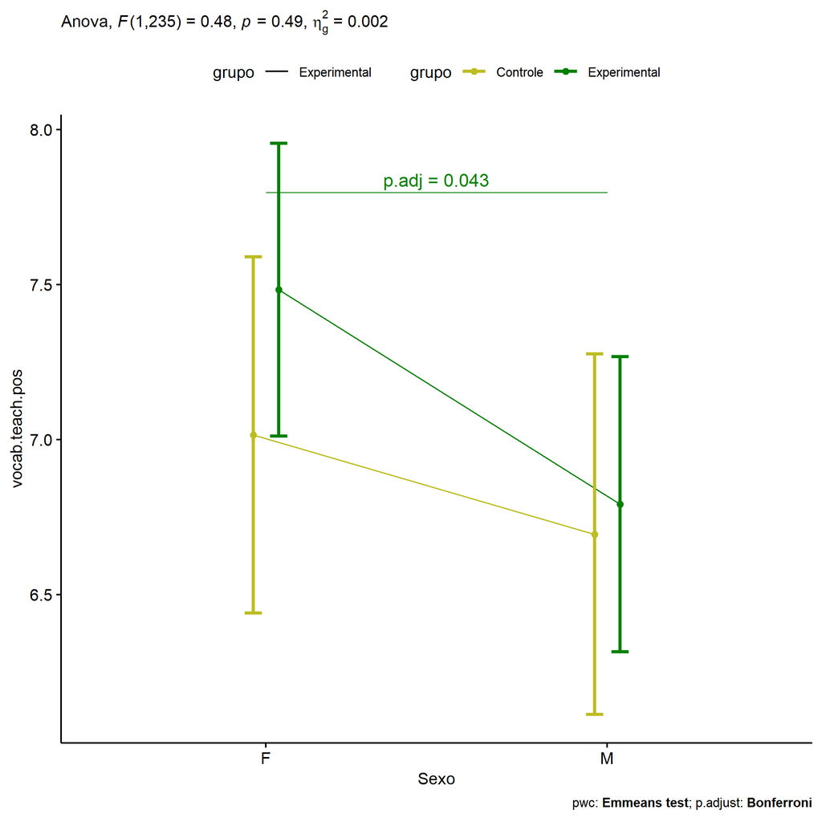

```r
if (!is.null(plots[["Sexo"]]))
  plots[["Sexo"]] + ggplot2::scale_color_manual(values = color[["grupo"]])
```

```r
plots <- twoWayAncovaBoxPlots(
  wdat, "vocab.teach.pos", c("grupo","Sexo"), aov, pwcs, covar = "vocab.teach.pre",
  theme = "classic", color = color[["grupo:Sexo"]],
  subtitle = which(aov$Effect == "grupo:Sexo"))
```

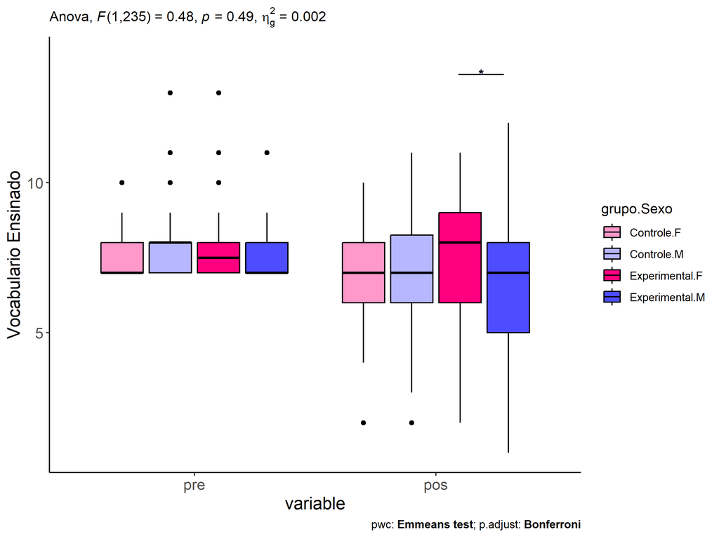

```r
plots[["grupo:Sexo"]] + ggplot2::ylab("Vocabulario Ensinado") + ggplot2::scale_x_discrete(labels=c('pre', 'pos'))
```

```r
plots <- twoWayAncovaBoxPlots(
  wdat.long, "vocab.teach", c("grupo","Sexo"), aov, pwc.long, pre.post = "time",
  theme = "classic", color = color$prepost)
```

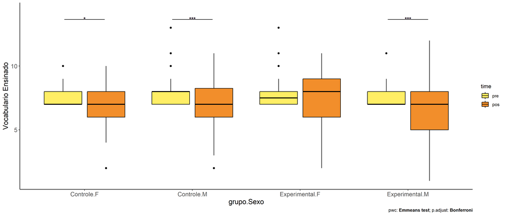

```r
plots[["grupo:Sexo"]] + ggplot2::ylab("Vocabulario Ensinado")
```

### Checking linearity assumption

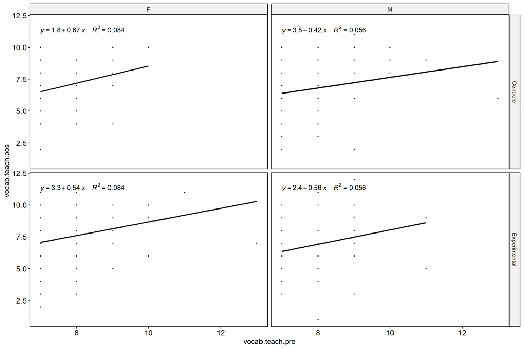

```r
ggscatter(wdat, x = "vocab.teach.pre", y = "vocab.teach.pos", size = 0.5,
          facet.by = c("grupo","Sexo"), add = "reg.line")+
  stat_regline_equation(
    aes(label =  paste(..eq.label.., ..rr.label.., sep = "~~~~"))
  )
```

### Checking normality and homogeneity

```r
res <- augment(lm(vocab.teach.pos ~ vocab.teach.pre + grupo*Sexo, data = wdat))
```

```r
shapiro_test(res$.resid)
```

```
## # A tibble: 1 × 3
##   variable   statistic p.value
##   <chr>          <dbl>   <dbl>
## 1 res$.resid     0.989  0.0718
```

```r
levene_test(res, .resid ~ grupo*Sexo)
```

```
## # A tibble: 1 × 4
##     df1   df2 statistic     p
##   <int> <int>     <dbl> <dbl>
## 1     3   236     0.412 0.745
```

# ANCOVA and Pairwise for two factors **grupo:Zona**

## Without remove non-normal data

```r
pdat = remove_group_data(dat[!is.na(dat[["grupo"]]) & !is.na(dat[["Zona"]]),], "vocab.teach.pos", c("grupo","Zona"))

pdat.long <- rbind(pdat[,c("id","grupo","Zona")], pdat[,c("id","grupo","Zona")])
pdat.long[["time"]] <- c(rep("pre", nrow(pdat)), rep("pos", nrow(pdat)))
pdat.long[["time"]] <- factor(pdat.long[["time"]], c("pre","pos"))
pdat.long[["vocab.teach"]] <- c(pdat[["vocab.teach.pre"]], pdat[["vocab.teach.pos"]])

aov = anova_test(pdat, vocab.teach.pos ~ vocab.teach.pre + grupo*Zona)
laov[["grupo:Zona"]] <- get_anova_table(aov)
```

```r
pwcs <- list()
pwcs[["Zona"]] <- emmeans_test(
  group_by(pdat, grupo), vocab.teach.pos ~ Zona,
  covariate = vocab.teach.pre, p.adjust.method = "bonferroni")
pwcs[["grupo"]] <- emmeans_test(
  group_by(pdat, Zona), vocab.teach.pos ~ grupo,
  covariate = vocab.teach.pre, p.adjust.method = "bonferroni")

pwc <- plyr::rbind.fill(pwcs[["grupo"]], pwcs[["Zona"]])
pwc <- pwc[,c("grupo","Zona", colnames(pwc)[!colnames(pwc) %in% c("grupo","Zona")])]
```

```r
pwc.long <- emmeans_test(dplyr::group_by_at(pdat.long, c("grupo","Zona")),
                         vocab.teach ~ time,
                         p.adjust.method = "bonferroni")
lpwc[["grupo:Zona"]] <- plyr::rbind.fill(pwc, pwc.long)
```

```r
ds <- get.descriptives(pdat, "vocab.teach.pos", c("grupo","Zona"), covar = "vocab.teach.pre")
ds <- merge(ds[ds$variable != "vocab.teach.pre",],
            ds[ds$variable == "vocab.teach.pre", !colnames(ds) %in% c("variable")],
            by = c("grupo","Zona"), all.x = T, suffixes = c("", ".vocab.teach.pre"))
ds <- merge(get_emmeans(pwcs[["grupo"]]), ds, by = c("grupo","Zona"), suffixes = c(".emms", ""))
ds <- ds[,c("grupo","Zona","n","mean.vocab.teach.pre","se.vocab.teach.pre","mean","se","emmean","se.emms")]

colnames(ds) <- c("grupo","Zona", "N", paste0(c("M","SE")," (pre)"),
                  paste0(c("M","SE"), " (unadj)"), paste0(c("M", "SE"), " (adj)"))

lemms[["grupo:Zona"]] <- ds
```

## Computing ANCOVA and PairWise After removing non-normal data (OK)

```r
wdat = pdat

res = residuals(lm(vocab.teach.pos ~ vocab.teach.pre + grupo*Zona, data = wdat))
non.normal = getNonNormal(res, wdat$id, plimit = 0.05)

wdat = wdat[!wdat$id %in% non.normal,]

wdat.long <- rbind(wdat[,c("id","grupo","Zona")], wdat[,c("id","grupo","Zona")])
wdat.long[["time"]] <- c(rep("pre", nrow(wdat)), rep("pos", nrow(wdat)))
wdat.long[["time"]] <- factor(wdat.long[["time"]], c("pre","pos"))
wdat.long[["vocab.teach"]] <- c(wdat[["vocab.teach.pre"]], wdat[["vocab.teach.pos"]])


ldat[["grupo:Zona"]] = wdat

(non.normal)
```

```r
aov = anova_test(wdat, vocab.teach.pos ~ vocab.teach.pre + grupo*Zona)
laov[["grupo:Zona"]] <- merge(get_anova_table(aov), laov[["grupo:Zona"]], by="Effect", suffixes = c("","'"))

(df = get_anova_table(aov))
```

```
## ANOVA Table (type II tests)
##
##            Effect DFn DFd     F     p p<.05      ges
## 1 vocab.teach.pre   1 160 9.218 0.003     * 0.054000
## 2           grupo   1 160 0.879 0.350       0.005000
## 3            Zona   1 160 0.594 0.442       0.004000
## 4      grupo:Zona   1 160 0.134 0.714       0.000839
```

| Effect | DFn | DFd | F | p | p<.05 | ges |
| --- | --- | --- | --- | --- | --- | --- |
| vocab.teach.pre | 1 | 160 | 9.218 | 0.003 | * | 0.054 |
| grupo | 1 | 160 | 0.879 | 0.350 |  | 0.005 |
| Zona | 1 | 160 | 0.594 | 0.442 |  | 0.004 |
| grupo:Zona | 1 | 160 | 0.134 | 0.714 |  | 0.001 |

```r
pwcs <- list()
pwcs[["Zona"]] <- emmeans_test(
  group_by(wdat, grupo), vocab.teach.pos ~ Zona,
  covariate = vocab.teach.pre, p.adjust.method = "bonferroni")
pwcs[["grupo"]] <- emmeans_test(
  group_by(wdat, Zona), vocab.teach.pos ~ grupo,
  covariate = vocab.teach.pre, p.adjust.method = "bonferroni")

pwc <- plyr::rbind.fill(pwcs[["grupo"]], pwcs[["Zona"]])
pwc <- pwc[,c("grupo","Zona", colnames(pwc)[!colnames(pwc) %in% c("grupo","Zona")])]
```

| grupo | Zona | term | .y. | group1 | group2 | df | statistic | p | p.adj | p.adj.signif |
| --- | --- | --- | --- | --- | --- | --- | --- | --- | --- | --- |
|  | Rural | vocab.teach.pre*grupo | vocab.teach.pos | Controle | Experimental | 160 | -0.567 | 0.571 | 0.571 | ns |
|  | Urbana | vocab.teach.pre*grupo | vocab.teach.pos | Controle | Experimental | 160 | -0.833 | 0.406 | 0.406 | ns |
| Controle |  | vocab.teach.pre*Zona | vocab.teach.pos | Rural | Urbana | 160 | 0.752 | 0.453 | 0.453 | ns |
| Experimental |  | vocab.teach.pre*Zona | vocab.teach.pos | Rural | Urbana | 160 | 0.403 | 0.687 | 0.687 | ns |

```r
pwc.long <- emmeans_test(dplyr::group_by_at(wdat.long, c("grupo","Zona")),
                         vocab.teach ~ time,
                         p.adjust.method = "bonferroni")
lpwc[["grupo:Zona"]] <- merge(plyr::rbind.fill(pwc, pwc.long), lpwc[["grupo:Zona"]], by=c("grupo","Zona","term",".y.","group1","group2"), suffixes = c("","'"))
```

| grupo | Zona | term | .y. | group1 | group2 | df | statistic | p | p.adj | p.adj.signif |
| --- | --- | --- | --- | --- | --- | --- | --- | --- | --- | --- |
| Controle | Rural | time | vocab.teach | pre | pos | 322 | 1.714 | 0.087 | 0.087 | ns |
| Controle | Urbana | time | vocab.teach | pre | pos | 322 | 1.827 | 0.069 | 0.069 | ns |
| Experimental | Rural | time | vocab.teach | pre | pos | 322 | 1.323 | 0.187 | 0.187 | ns |
| Experimental | Urbana | time | vocab.teach | pre | pos | 322 | 1.906 | 0.058 | 0.058 | ns |

```r
ds <- get.descriptives(wdat, "vocab.teach.pos", c("grupo","Zona"), covar = "vocab.teach.pre")
ds <- merge(ds[ds$variable != "vocab.teach.pre",],
            ds[ds$variable == "vocab.teach.pre", !colnames(ds) %in% c("variable")],
            by = c("grupo","Zona"), all.x = T, suffixes = c("", ".vocab.teach.pre"))
ds <- merge(get_emmeans(pwcs[["grupo"]]), ds, by = c("grupo","Zona"), suffixes = c(".emms", ""))
ds <- ds[,c("grupo","Zona","n","mean.vocab.teach.pre","se.vocab.teach.pre","mean","se","emmean","se.emms")]

colnames(ds) <- c("grupo","Zona", "N", paste0(c("M","SE")," (pre)"),
                  paste0(c("M","SE"), " (unadj)"), paste0(c("M", "SE"), " (adj)"))

lemms[["grupo:Zona"]] <- merge(ds, lemms[["grupo:Zona"]], by=c("grupo","Zona"), suffixes = c("","'"))
```

| grupo | Zona | N | M (pre) | SE (pre) | M (unadj) | SE (unadj) | M (adj) | SE (adj) |
| --- | --- | --- | --- | --- | --- | --- | --- | --- |
| Controle | Rural | 46 | 7.630 | 0.140 | 7.043 | 0.298 | 7.089 | 0.299 |
| Controle | Urbana | 18 | 7.611 | 0.231 | 6.611 | 0.354 | 6.665 | 0.478 |
| Experimental | Rural | 61 | 7.689 | 0.125 | 7.295 | 0.288 | 7.313 | 0.259 |
| Experimental | Urbana | 40 | 7.950 | 0.196 | 7.250 | 0.330 | 7.146 | 0.322 |

### Plots for ancova

```r
plots <- twoWayAncovaPlots(
  wdat, "vocab.teach.pos", c("grupo","Zona"), aov, pwcs, addParam = c("mean_se"),
  font.label.size=10, step.increase=0.05, p.label="p.adj",
  subtitle = which(aov$Effect == "grupo:Zona"))
```

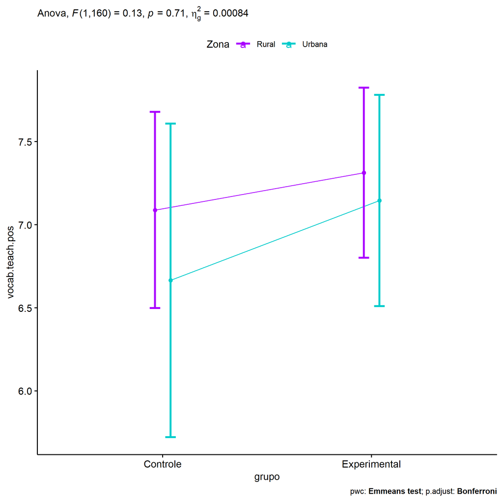

```r
if (!is.null(plots[["grupo"]]))
  plots[["grupo"]] + ggplot2::scale_color_manual(values = color[["Zona"]])
```

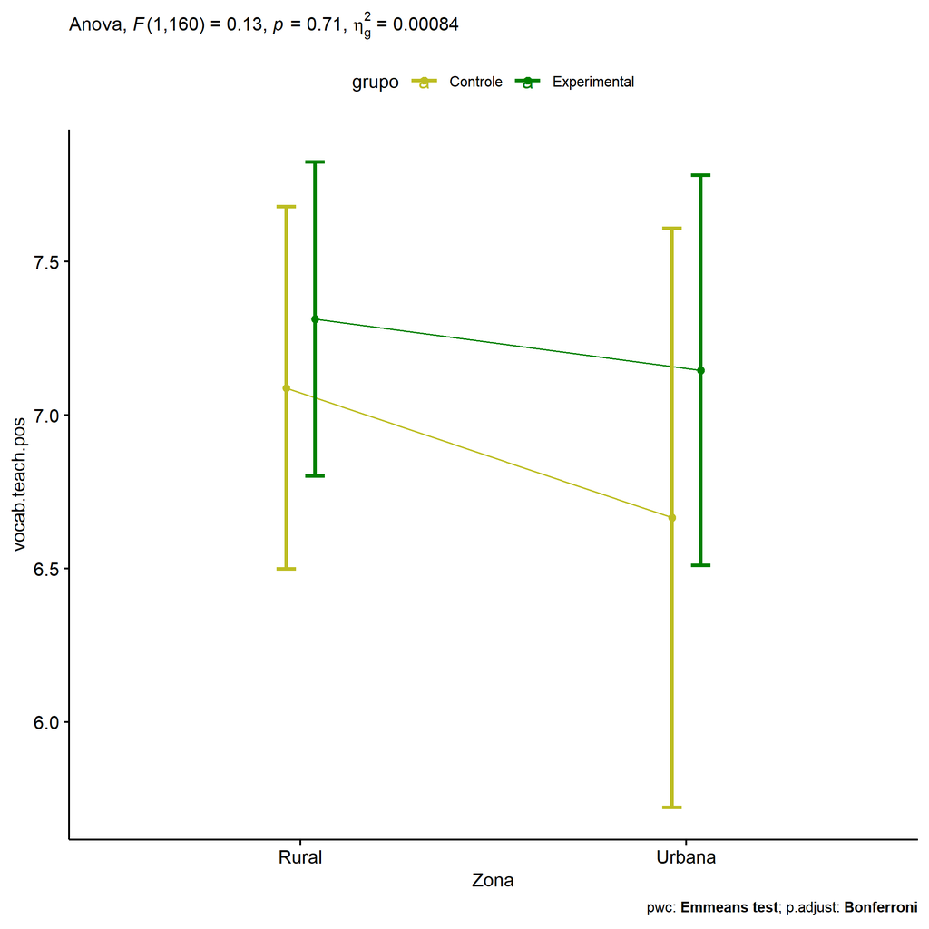

```r
if (!is.null(plots[["Zona"]]))
  plots[["Zona"]] + ggplot2::scale_color_manual(values = color[["grupo"]])
```

```r
plots <- twoWayAncovaBoxPlots(
  wdat, "vocab.teach.pos", c("grupo","Zona"), aov, pwcs, covar = "vocab.teach.pre",
  theme = "classic", color = color[["grupo:Zona"]],
  subtitle = which(aov$Effect == "grupo:Zona"))
```

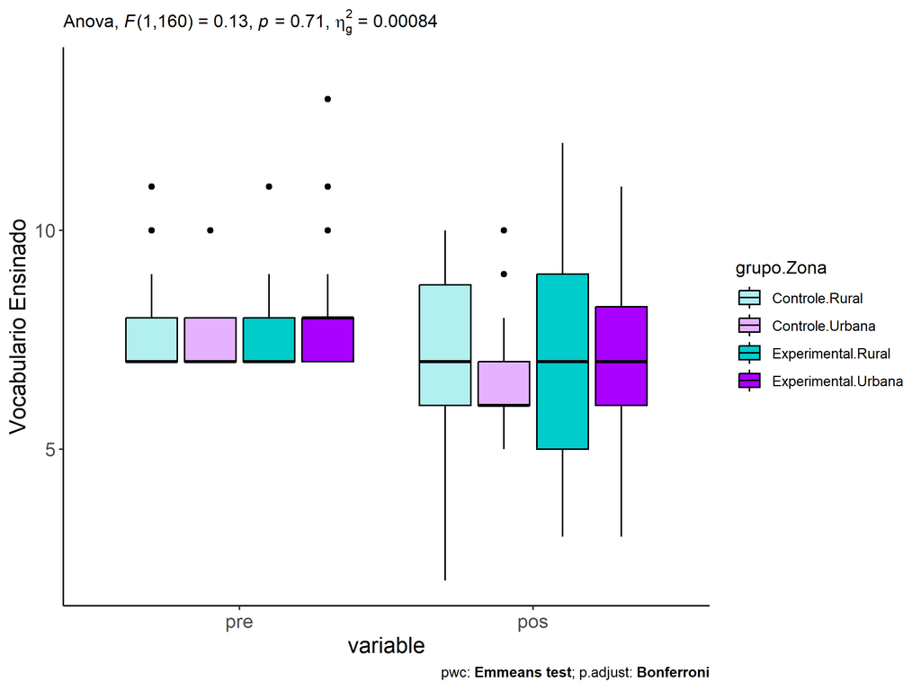

```r
plots[["grupo:Zona"]] + ggplot2::ylab("Vocabulario Ensinado") + ggplot2::scale_x_discrete(labels=c('pre', 'pos'))
```

```r
plots <- twoWayAncovaBoxPlots(
  wdat.long, "vocab.teach", c("grupo","Zona"), aov, pwc.long, pre.post = "time",
  theme = "classic", color = color$prepost)
```

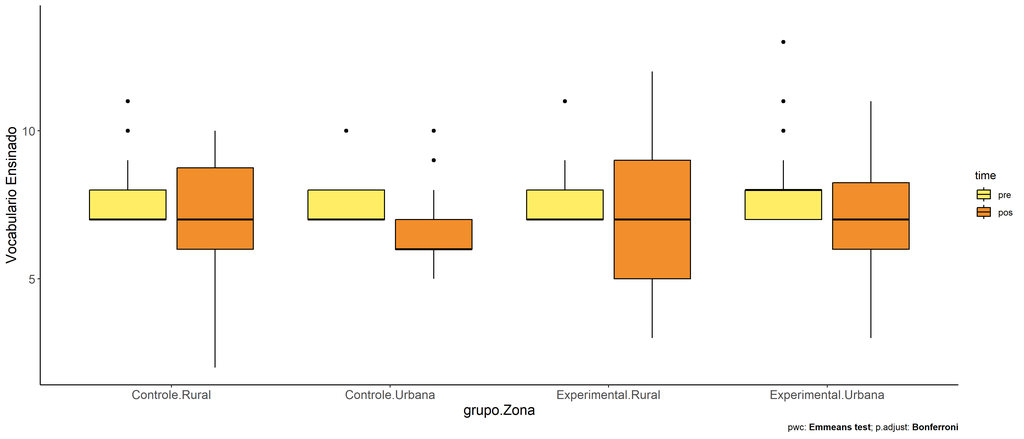

```r
plots[["grupo:Zona"]] + ggplot2::ylab("Vocabulario Ensinado")
```

### Checking linearity assumption

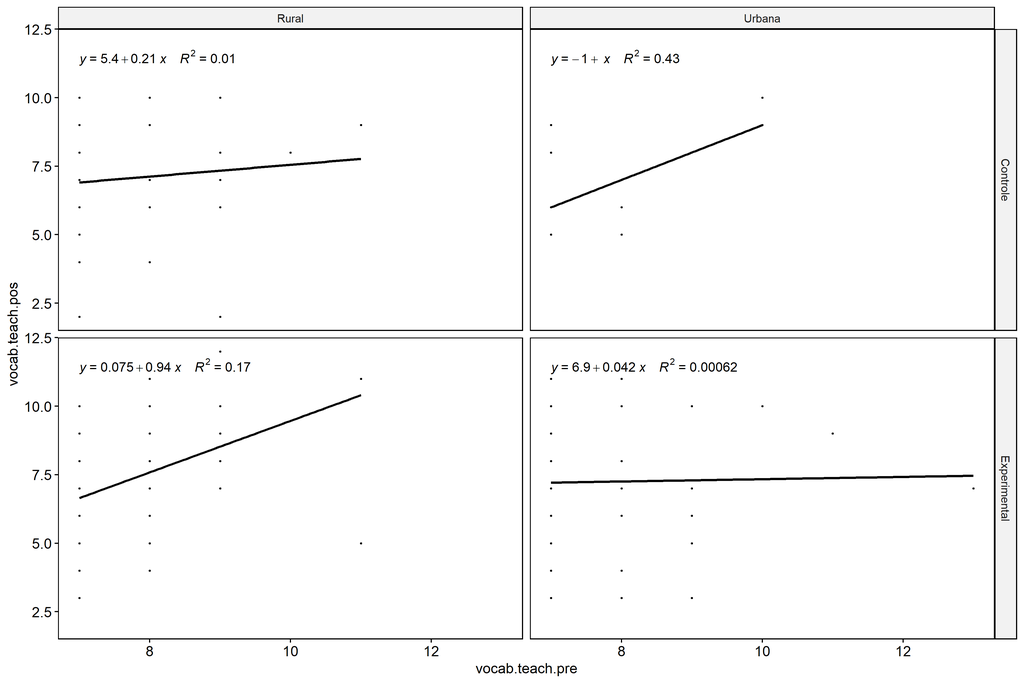

```r
ggscatter(wdat, x = "vocab.teach.pre", y = "vocab.teach.pos", size = 0.5,
          facet.by = c("grupo","Zona"), add = "reg.line")+
  stat_regline_equation(
    aes(label =  paste(..eq.label.., ..rr.label.., sep = "~~~~"))
  )
```

### Checking normality and homogeneity

```r
res <- augment(lm(vocab.teach.pos ~ vocab.teach.pre + grupo*Zona, data = wdat))
```

```r
shapiro_test(res$.resid)
```

```
## # A tibble: 1 × 3
##   variable   statistic p.value
##   <chr>          <dbl>   <dbl>
## 1 res$.resid     0.987   0.129
```

```r
levene_test(res, .resid ~ grupo*Zona)
```

```
## # A tibble: 1 × 4
##     df1   df2 statistic      p
##   <int> <int>     <dbl>  <dbl>
## 1     3   161      2.58 0.0554
```

# ANCOVA and Pairwise for two factors **grupo:Cor.Raca**

## Without remove non-normal data

```r
pdat = remove_group_data(dat[!is.na(dat[["grupo"]]) & !is.na(dat[["Cor.Raca"]]),], "vocab.teach.pos", c("grupo","Cor.Raca"))
pdat.long <- rbind(pdat[,c("id","grupo","Cor.Raca")], pdat[,c("id","grupo","Cor.Raca")])
pdat.long[["time"]] <- c(rep("pre", nrow(pdat)), rep("pos", nrow(pdat)))
pdat.long[["time"]] <- factor(pdat.long[["time"]], c("pre","pos"))
pdat.long[["vocab.teach"]] <- c(pdat[["vocab.teach.pre"]], pdat[["vocab.teach.pos"]])

aov = anova_test(pdat, vocab.teach.pos ~ vocab.teach.pre + grupo*Cor.Raca)
laov[["grupo:Cor.Raca"]] <- get_anova_table(aov)
```

```r
pwcs <- list()
pwcs[["Cor.Raca"]] <- emmeans_test(
  group_by(pdat, grupo), vocab.teach.pos ~ Cor.Raca,
  covariate = vocab.teach.pre, p.adjust.method = "bonferroni")
pwcs[["grupo"]] <- emmeans_test(
  group_by(pdat, Cor.Raca), vocab.teach.pos ~ grupo,
  covariate = vocab.teach.pre, p.adjust.method = "bonferroni")

pwc <- plyr::rbind.fill(pwcs[["grupo"]], pwcs[["Cor.Raca"]])
pwc <- pwc[,c("grupo","Cor.Raca", colnames(pwc)[!colnames(pwc) %in% c("grupo","Cor.Raca")])]
```

```r
pwc.long <- emmeans_test(dplyr::group_by_at(pdat.long, c("grupo","Cor.Raca")),
                         vocab.teach ~ time,
                         p.adjust.method = "bonferroni")
lpwc[["grupo:Cor.Raca"]] <- plyr::rbind.fill(pwc, pwc.long)
```

```r
ds <- get.descriptives(pdat, "vocab.teach.pos", c("grupo","Cor.Raca"), covar = "vocab.teach.pre")
ds <- merge(ds[ds$variable != "vocab.teach.pre",],
            ds[ds$variable == "vocab.teach.pre", !colnames(ds) %in% c("variable")],
            by = c("grupo","Cor.Raca"), all.x = T, suffixes = c("", ".vocab.teach.pre"))
ds <- merge(get_emmeans(pwcs[["grupo"]]), ds, by = c("grupo","Cor.Raca"), suffixes = c(".emms", ""))
ds <- ds[,c("grupo","Cor.Raca","n","mean.vocab.teach.pre","se.vocab.teach.pre","mean","se","emmean","se.emms")]

colnames(ds) <- c("grupo","Cor.Raca", "N", paste0(c("M","SE")," (pre)"),
                  paste0(c("M","SE"), " (unadj)"), paste0(c("M", "SE"), " (adj)"))

lemms[["grupo:Cor.Raca"]] <- ds
```

## Computing ANCOVA and PairWise After removing non-normal data (OK)

```r
wdat = pdat

res = residuals(lm(vocab.teach.pos ~ vocab.teach.pre + grupo*Cor.Raca, data = wdat))
non.normal = getNonNormal(res, wdat$id, plimit = 0.05)

wdat = wdat[!wdat$id %in% non.normal,]

wdat.long <- rbind(wdat[,c("id","grupo","Cor.Raca")], wdat[,c("id","grupo","Cor.Raca")])
wdat.long[["time"]] <- c(rep("pre", nrow(wdat)), rep("pos", nrow(wdat)))
wdat.long[["time"]] <- factor(wdat.long[["time"]], c("pre","pos"))
wdat.long[["vocab.teach"]] <- c(wdat[["vocab.teach.pre"]], wdat[["vocab.teach.pos"]])


ldat[["grupo:Cor.Raca"]] = wdat

(non.normal)
```

```r
aov = anova_test(wdat, vocab.teach.pos ~ vocab.teach.pre + grupo*Cor.Raca)
laov[["grupo:Cor.Raca"]] <- merge(get_anova_table(aov), laov[["grupo:Cor.Raca"]], by="Effect", suffixes = c("","'"))

(df = get_anova_table(aov))
```

```
## ANOVA Table (type II tests)
##
##            Effect DFn DFd      F        p p<.05   ges
## 1 vocab.teach.pre   1  81 13.846 0.000365     * 0.146
## 2           grupo   1  81  0.532 0.468000       0.007
## 3        Cor.Raca   1  81  0.411 0.523000       0.005
## 4  grupo:Cor.Raca   1  81  0.085 0.771000       0.001
```

| Effect | DFn | DFd | F | p | p<.05 | ges |
| --- | --- | --- | --- | --- | --- | --- |
| vocab.teach.pre | 1 | 81 | 13.846 | 0.000 | * | 0.146 |
| grupo | 1 | 81 | 0.532 | 0.468 |  | 0.007 |
| Cor.Raca | 1 | 81 | 0.411 | 0.523 |  | 0.005 |
| grupo:Cor.Raca | 1 | 81 | 0.085 | 0.771 |  | 0.001 |

```r
pwcs <- list()
pwcs[["Cor.Raca"]] <- emmeans_test(
  group_by(wdat, grupo), vocab.teach.pos ~ Cor.Raca,
  covariate = vocab.teach.pre, p.adjust.method = "bonferroni")
pwcs[["grupo"]] <- emmeans_test(
  group_by(wdat, Cor.Raca), vocab.teach.pos ~ grupo,
  covariate = vocab.teach.pre, p.adjust.method = "bonferroni")

pwc <- plyr::rbind.fill(pwcs[["grupo"]], pwcs[["Cor.Raca"]])
pwc <- pwc[,c("grupo","Cor.Raca", colnames(pwc)[!colnames(pwc) %in% c("grupo","Cor.Raca")])]
```

| grupo | Cor.Raca | term | .y. | group1 | group2 | df | statistic | p | p.adj | p.adj.signif |
| --- | --- | --- | --- | --- | --- | --- | --- | --- | --- | --- |
|  | Branca | vocab.teach.pre*grupo | vocab.teach.pos | Controle | Experimental | 81 | -0.620 | 0.537 | 0.537 | ns |
|  | Parda | vocab.teach.pre*grupo | vocab.teach.pos | Controle | Experimental | 81 | -0.481 | 0.632 | 0.632 | ns |
| Controle |  | vocab.teach.pre*Cor.Raca | vocab.teach.pos | Branca | Parda | 81 | 0.188 | 0.851 | 0.851 | ns |
| Experimental |  | vocab.teach.pre*Cor.Raca | vocab.teach.pos | Branca | Parda | 81 | 0.678 | 0.500 | 0.500 | ns |

```r
pwc.long <- emmeans_test(dplyr::group_by_at(wdat.long, c("grupo","Cor.Raca")),
                         vocab.teach ~ time,
                         p.adjust.method = "bonferroni")
lpwc[["grupo:Cor.Raca"]] <- merge(plyr::rbind.fill(pwc, pwc.long), lpwc[["grupo:Cor.Raca"]], by=c("grupo","Cor.Raca","term",".y.","group1","group2"), suffixes = c("","'"))
```

| grupo | Cor.Raca | term | .y. | group1 | group2 | df | statistic | p | p.adj | p.adj.signif |
| --- | --- | --- | --- | --- | --- | --- | --- | --- | --- | --- |
| Controle | Branca | time | vocab.teach | pre | pos | 164 | 0.912 | 0.363 | 0.363 | ns |
| Controle | Parda | time | vocab.teach | pre | pos | 164 | 1.886 | 0.061 | 0.061 | ns |
| Experimental | Branca | time | vocab.teach | pre | pos | 164 | 0.104 | 0.917 | 0.917 | ns |
| Experimental | Parda | time | vocab.teach | pre | pos | 164 | 1.474 | 0.142 | 0.142 | ns |

```r
ds <- get.descriptives(wdat, "vocab.teach.pos", c("grupo","Cor.Raca"), covar = "vocab.teach.pre")
ds <- merge(ds[ds$variable != "vocab.teach.pre",],
            ds[ds$variable == "vocab.teach.pre", !colnames(ds) %in% c("variable")],
            by = c("grupo","Cor.Raca"), all.x = T, suffixes = c("", ".vocab.teach.pre"))
ds <- merge(get_emmeans(pwcs[["grupo"]]), ds, by = c("grupo","Cor.Raca"), suffixes = c(".emms", ""))
ds <- ds[,c("grupo","Cor.Raca","n","mean.vocab.teach.pre","se.vocab.teach.pre","mean","se","emmean","se.emms")]

colnames(ds) <- c("grupo","Cor.Raca", "N", paste0(c("M","SE")," (pre)"),
                  paste0(c("M","SE"), " (unadj)"), paste0(c("M", "SE"), " (adj)"))

lemms[["grupo:Cor.Raca"]] <- merge(ds, lemms[["grupo:Cor.Raca"]], by=c("grupo","Cor.Raca"), suffixes = c("","'"))
```

| grupo | Cor.Raca | N | M (pre) | SE (pre) | M (unadj) | SE (unadj) | M (adj) | SE (adj) |
| --- | --- | --- | --- | --- | --- | --- | --- | --- |
| Controle | Branca | 9 | 8.000 | 0.471 | 7.222 | 0.778 | 7.056 | 0.716 |
| Controle | Parda | 29 | 7.828 | 0.258 | 6.931 | 0.391 | 6.902 | 0.398 |
| Experimental | Branca | 14 | 7.357 | 0.133 | 7.286 | 0.485 | 7.630 | 0.581 |
| Experimental | Parda | 34 | 7.882 | 0.157 | 7.235 | 0.449 | 7.162 | 0.368 |

### Plots for ancova

```r
plots <- twoWayAncovaPlots(
  wdat, "vocab.teach.pos", c("grupo","Cor.Raca"), aov, pwcs, addParam = c("mean_se"),
  font.label.size=10, step.increase=0.05, p.label="p.adj",
  subtitle = which(aov$Effect == "grupo:Cor.Raca"))
```

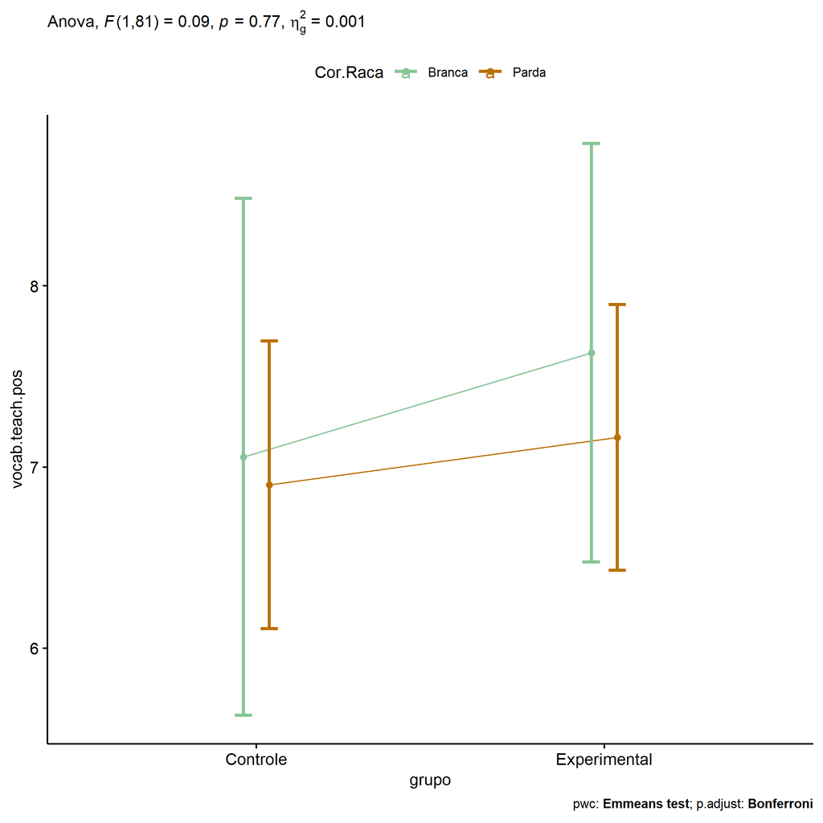

```r
if (!is.null(plots[["grupo"]]))
  plots[["grupo"]] + ggplot2::scale_color_manual(values = color[["Cor.Raca"]])
```

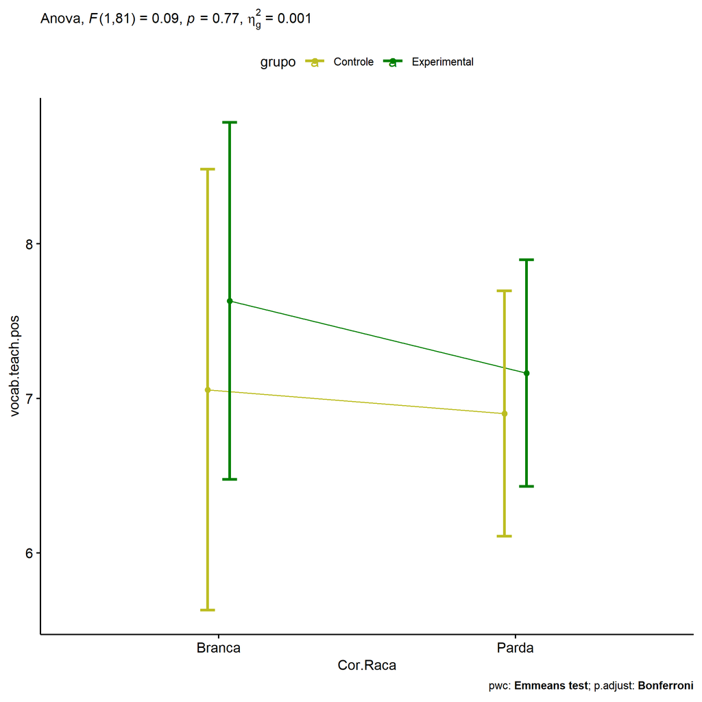

```r
if (!is.null(plots[["Cor.Raca"]]))
  plots[["Cor.Raca"]] + ggplot2::scale_color_manual(values = color[["grupo"]])
```

```r
plots <- twoWayAncovaBoxPlots(
  wdat, "vocab.teach.pos", c("grupo","Cor.Raca"), aov, pwcs, covar = "vocab.teach.pre",
  theme = "classic", color = color[["grupo:Cor.Raca"]],
  subtitle = which(aov$Effect == "grupo:Cor.Raca"))
```

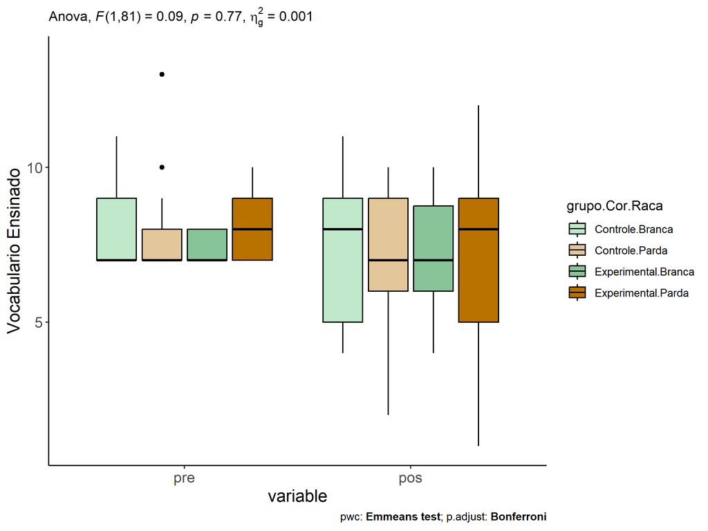

```r
plots[["grupo:Cor.Raca"]] + ggplot2::ylab("Vocabulario Ensinado") + ggplot2::scale_x_discrete(labels=c('pre', 'pos'))
```

```r
plots <- twoWayAncovaBoxPlots(
  wdat.long, "vocab.teach", c("grupo","Cor.Raca"), aov, pwc.long, pre.post = "time",
  theme = "classic", color = color$prepost)
```

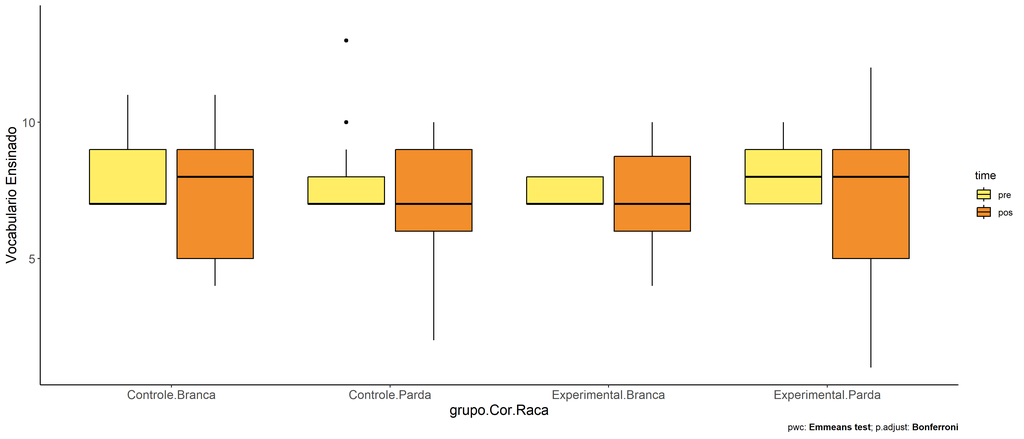

```r
plots[["grupo:Cor.Raca"]] + ggplot2::ylab("Vocabulario Ensinado")
```

### Checking linearity assumption

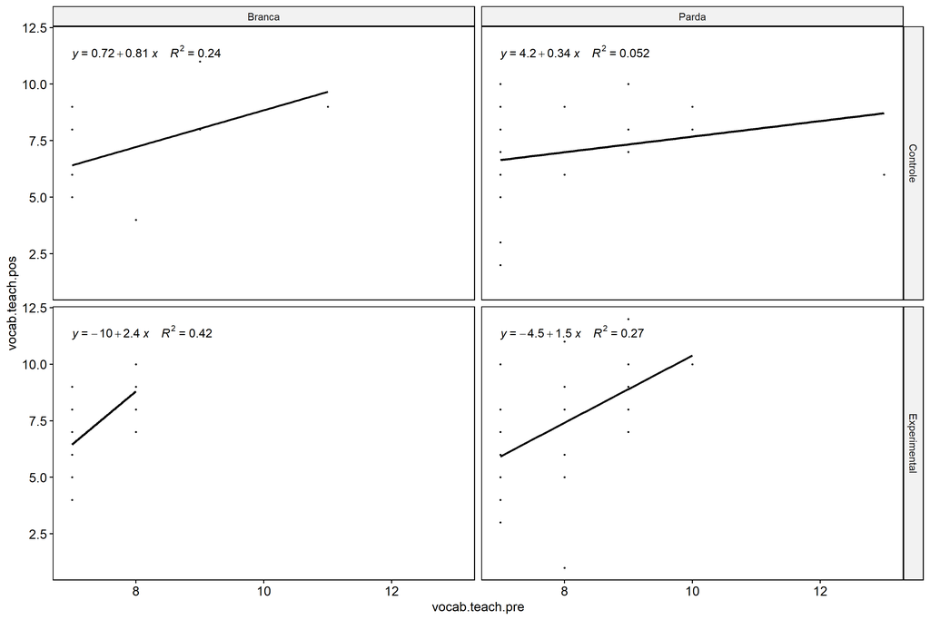

```r
ggscatter(wdat, x = "vocab.teach.pre", y = "vocab.teach.pos", size = 0.5,
          facet.by = c("grupo","Cor.Raca"), add = "reg.line")+
  stat_regline_equation(
    aes(label =  paste(..eq.label.., ..rr.label.., sep = "~~~~"))
  )
```

### Checking normality and homogeneity

```r
res <- augment(lm(vocab.teach.pos ~ vocab.teach.pre + grupo*Cor.Raca, data = wdat))
```

```r
shapiro_test(res$.resid)
```

```
## # A tibble: 1 × 3
##   variable   statistic p.value
##   <chr>          <dbl>   <dbl>
## 1 res$.resid     0.979   0.165
```

```r
levene_test(res, .resid ~ grupo*Cor.Raca)
```

```
## # A tibble: 1 × 4
##     df1   df2 statistic     p
##   <int> <int>     <dbl> <dbl>
## 1     3    82     0.770 0.514
```

# ANCOVA and Pairwise for two factors **grupo:Serie**

## Without remove non-normal data

```r
pdat = remove_group_data(dat[!is.na(dat[["grupo"]]) & !is.na(dat[["Serie"]]),], "vocab.teach.pos", c("grupo","Serie"))

pdat.long <- rbind(pdat[,c("id","grupo","Serie")], pdat[,c("id","grupo","Serie")])
pdat.long[["time"]] <- c(rep("pre", nrow(pdat)), rep("pos", nrow(pdat)))
pdat.long[["time"]] <- factor(pdat.long[["time"]], c("pre","pos"))
pdat.long[["vocab.teach"]] <- c(pdat[["vocab.teach.pre"]], pdat[["vocab.teach.pos"]])

aov = anova_test(pdat, vocab.teach.pos ~ vocab.teach.pre + grupo*Serie)
laov[["grupo:Serie"]] <- get_anova_table(aov)
```

```r
pwcs <- list()
pwcs[["Serie"]] <- emmeans_test(
  group_by(pdat, grupo), vocab.teach.pos ~ Serie,
  covariate = vocab.teach.pre, p.adjust.method = "bonferroni")
pwcs[["grupo"]] <- emmeans_test(
  group_by(pdat, Serie), vocab.teach.pos ~ grupo,
  covariate = vocab.teach.pre, p.adjust.method = "bonferroni")

pwc <- plyr::rbind.fill(pwcs[["grupo"]], pwcs[["Serie"]])
pwc <- pwc[,c("grupo","Serie", colnames(pwc)[!colnames(pwc) %in% c("grupo","Serie")])]
```

```r
pwc.long <- emmeans_test(dplyr::group_by_at(pdat.long, c("grupo","Serie")),
                         vocab.teach ~ time,
                         p.adjust.method = "bonferroni")
lpwc[["grupo:Serie"]] <- plyr::rbind.fill(pwc, pwc.long)
```

```r
ds <- get.descriptives(pdat, "vocab.teach.pos", c("grupo","Serie"), covar = "vocab.teach.pre")
ds <- merge(ds[ds$variable != "vocab.teach.pre",],
            ds[ds$variable == "vocab.teach.pre", !colnames(ds) %in% c("variable")],
            by = c("grupo","Serie"), all.x = T, suffixes = c("", ".vocab.teach.pre"))
ds <- merge(get_emmeans(pwcs[["grupo"]]), ds, by = c("grupo","Serie"), suffixes = c(".emms", ""))
ds <- ds[,c("grupo","Serie","n","mean.vocab.teach.pre","se.vocab.teach.pre","mean","se","emmean","se.emms")]

colnames(ds) <- c("grupo","Serie", "N", paste0(c("M","SE")," (pre)"),
                  paste0(c("M","SE"), " (unadj)"), paste0(c("M", "SE"), " (adj)"))

lemms[["grupo:Serie"]] <- ds
```

## Computing ANCOVA and PairWise After removing non-normal data (OK)

```r
wdat = pdat

res = residuals(lm(vocab.teach.pos ~ vocab.teach.pre + grupo*Serie, data = wdat))
non.normal = getNonNormal(res, wdat$id, plimit = 0.05)

wdat = wdat[!wdat$id %in% non.normal,]

wdat.long <- rbind(wdat[,c("id","grupo","Serie")], wdat[,c("id","grupo","Serie")])
wdat.long[["time"]] <- c(rep("pre", nrow(wdat)), rep("pos", nrow(wdat)))
wdat.long[["time"]] <- factor(wdat.long[["time"]], c("pre","pos"))
wdat.long[["vocab.teach"]] <- c(wdat[["vocab.teach.pre"]], wdat[["vocab.teach.pos"]])


ldat[["grupo:Serie"]] = wdat

(non.normal)
```

```r
aov = anova_test(wdat, vocab.teach.pos ~ vocab.teach.pre + grupo*Serie)
laov[["grupo:Serie"]] <- merge(get_anova_table(aov), laov[["grupo:Serie"]], by="Effect", suffixes = c("","'"))

(df = get_anova_table(aov))
```

```
## ANOVA Table (type II tests)
##
##            Effect DFn DFd      F        p p<.05   ges
## 1 vocab.teach.pre   1 231 18.567 2.43e-05     * 0.074
## 2           grupo   1 231  2.485 1.16e-01       0.011
## 3           Serie   3 231  4.123 7.00e-03     * 0.051
## 4     grupo:Serie   3 231  0.862 4.61e-01       0.011
```

| Effect | DFn | DFd | F | p | p<.05 | ges |
| --- | --- | --- | --- | --- | --- | --- |
| vocab.teach.pre | 1 | 231 | 18.567 | 0.000 | * | 0.074 |
| grupo | 1 | 231 | 2.485 | 0.116 |  | 0.011 |
| Serie | 3 | 231 | 4.123 | 0.007 | * | 0.051 |
| grupo:Serie | 3 | 231 | 0.862 | 0.461 |  | 0.011 |

```r
pwcs <- list()
pwcs[["Serie"]] <- emmeans_test(
  group_by(wdat, grupo), vocab.teach.pos ~ Serie,
  covariate = vocab.teach.pre, p.adjust.method = "bonferroni")
pwcs[["grupo"]] <- emmeans_test(
  group_by(wdat, Serie), vocab.teach.pos ~ grupo,
  covariate = vocab.teach.pre, p.adjust.method = "bonferroni")

pwc <- plyr::rbind.fill(pwcs[["grupo"]], pwcs[["Serie"]])
pwc <- pwc[,c("grupo","Serie", colnames(pwc)[!colnames(pwc) %in% c("grupo","Serie")])]
```

| grupo | Serie | term | .y. | group1 | group2 | df | statistic | p | p.adj | p.adj.signif |
| --- | --- | --- | --- | --- | --- | --- | --- | --- | --- | --- |
|  | 6 ano | vocab.teach.pre*grupo | vocab.teach.pos | Controle | Experimental | 231 | -1.736 | 0.084 | 0.084 | ns |
|  | 7 ano | vocab.teach.pre*grupo | vocab.teach.pos | Controle | Experimental | 231 | 0.062 | 0.951 | 0.951 | ns |
|  | 8 ano | vocab.teach.pre*grupo | vocab.teach.pos | Controle | Experimental | 231 | -0.115 | 0.909 | 0.909 | ns |
|  | 9 ano | vocab.teach.pre*grupo | vocab.teach.pos | Controle | Experimental | 231 | -1.426 | 0.155 | 0.155 | ns |
| Controle |  | vocab.teach.pre*Serie | vocab.teach.pos | 6 ano | 7 ano | 231 | -0.888 | 0.376 | 1.000 | ns |
| Controle |  | vocab.teach.pre*Serie | vocab.teach.pos | 6 ano | 8 ano | 231 | -1.865 | 0.063 | 0.381 | ns |
| Controle |  | vocab.teach.pre*Serie | vocab.teach.pos | 6 ano | 9 ano | 231 | -2.129 | 0.034 | 0.206 | ns |
| Controle |  | vocab.teach.pre*Serie | vocab.teach.pos | 7 ano | 8 ano | 231 | -0.962 | 0.337 | 1.000 | ns |
| Controle |  | vocab.teach.pre*Serie | vocab.teach.pos | 7 ano | 9 ano | 231 | -1.169 | 0.244 | 1.000 | ns |
| Controle |  | vocab.teach.pre*Serie | vocab.teach.pos | 8 ano | 9 ano | 231 | -0.120 | 0.904 | 1.000 | ns |
| Experimental |  | vocab.teach.pre*Serie | vocab.teach.pos | 6 ano | 7 ano | 231 | 1.123 | 0.263 | 1.000 | ns |
| Experimental |  | vocab.teach.pre*Serie | vocab.teach.pos | 6 ano | 8 ano | 231 | -0.168 | 0.867 | 1.000 | ns |
| Experimental |  | vocab.teach.pre*Serie | vocab.teach.pos | 6 ano | 9 ano | 231 | -1.280 | 0.202 | 1.000 | ns |
| Experimental |  | vocab.teach.pre*Serie | vocab.teach.pos | 7 ano | 8 ano | 231 | -1.578 | 0.116 | 0.695 | ns |
| Experimental |  | vocab.teach.pre*Serie | vocab.teach.pos | 7 ano | 9 ano | 231 | -3.073 | 0.002 | 0.014 | * |
| Experimental |  | vocab.teach.pre*Serie | vocab.teach.pos | 8 ano | 9 ano | 231 | -1.367 | 0.173 | 1.000 | ns |

```r
pwc.long <- emmeans_test(dplyr::group_by_at(wdat.long, c("grupo","Serie")),
                         vocab.teach ~ time,
                         p.adjust.method = "bonferroni")
lpwc[["grupo:Serie"]] <- merge(plyr::rbind.fill(pwc, pwc.long), lpwc[["grupo:Serie"]], by=c("grupo","Serie","term",".y.","group1","group2"), suffixes = c("","'"))
```

| grupo | Serie | term | .y. | group1 | group2 | df | statistic | p | p.adj | p.adj.signif |
| --- | --- | --- | --- | --- | --- | --- | --- | --- | --- | --- |
| Controle | 6 ano | time | vocab.teach | pre | pos | 464 | 2.973 | 0.003 | 0.003 | ** |
| Controle | 7 ano | time | vocab.teach | pre | pos | 464 | 2.251 | 0.025 | 0.025 | * |
| Controle | 8 ano | time | vocab.teach | pre | pos | 464 | 1.225 | 0.221 | 0.221 | ns |
| Controle | 9 ano | time | vocab.teach | pre | pos | 464 | 1.939 | 0.053 | 0.053 | ns |
| Experimental | 6 ano | time | vocab.teach | pre | pos | 464 | 1.377 | 0.169 | 0.169 | ns |
| Experimental | 7 ano | time | vocab.teach | pre | pos | 464 | 3.816 | 0.000 | 0.000 | *** |
| Experimental | 8 ano | time | vocab.teach | pre | pos | 464 | 1.410 | 0.159 | 0.159 | ns |
| Experimental | 9 ano | time | vocab.teach | pre | pos | 464 | -0.063 | 0.950 | 0.950 | ns |

```r
ds <- get.descriptives(wdat, "vocab.teach.pos", c("grupo","Serie"), covar = "vocab.teach.pre")
ds <- merge(ds[ds$variable != "vocab.teach.pre",],
            ds[ds$variable == "vocab.teach.pre", !colnames(ds) %in% c("variable")],
            by = c("grupo","Serie"), all.x = T, suffixes = c("", ".vocab.teach.pre"))
ds <- merge(get_emmeans(pwcs[["grupo"]]), ds, by = c("grupo","Serie"), suffixes = c(".emms", ""))
ds <- ds[,c("grupo","Serie","n","mean.vocab.teach.pre","se.vocab.teach.pre","mean","se","emmean","se.emms")]

colnames(ds) <- c("grupo","Serie", "N", paste0(c("M","SE")," (pre)"),
                  paste0(c("M","SE"), " (unadj)"), paste0(c("M", "SE"), " (adj)"))

lemms[["grupo:Serie"]] <- merge(ds, lemms[["grupo:Serie"]], by=c("grupo","Serie"), suffixes = c("","'"))
```

| grupo | Serie | N | M (pre) | SE (pre) | M (unadj) | SE (unadj) | M (adj) | SE (adj) |
| --- | --- | --- | --- | --- | --- | --- | --- | --- |
| Controle | 6 ano | 13 | 7.692 | 0.263 | 5.769 | 0.533 | 5.814 | 0.557 |
| Controle | 7 ano | 16 | 7.812 | 0.292 | 6.500 | 0.483 | 6.480 | 0.502 |
| Controle | 8 ano | 24 | 7.583 | 0.180 | 7.000 | 0.404 | 7.104 | 0.411 |
| Controle | 9 ano | 44 | 7.932 | 0.173 | 7.250 | 0.307 | 7.165 | 0.303 |
| Experimental | 6 ano | 19 | 7.842 | 0.279 | 7.105 | 0.477 | 7.069 | 0.461 |
| Experimental | 7 ano | 41 | 7.902 | 0.200 | 6.512 | 0.389 | 6.443 | 0.314 |
| Experimental | 8 ano | 37 | 7.622 | 0.131 | 7.081 | 0.332 | 7.164 | 0.331 |
| Experimental | 9 ano | 46 | 7.717 | 0.131 | 7.739 | 0.282 | 7.770 | 0.296 |

### Plots for ancova

```r
plots <- twoWayAncovaPlots(
  wdat, "vocab.teach.pos", c("grupo","Serie"), aov, pwcs, addParam = c("mean_se"),
  font.label.size=10, step.increase=0.05, p.label="p.adj",
  subtitle = which(aov$Effect == "grupo:Serie"))
```

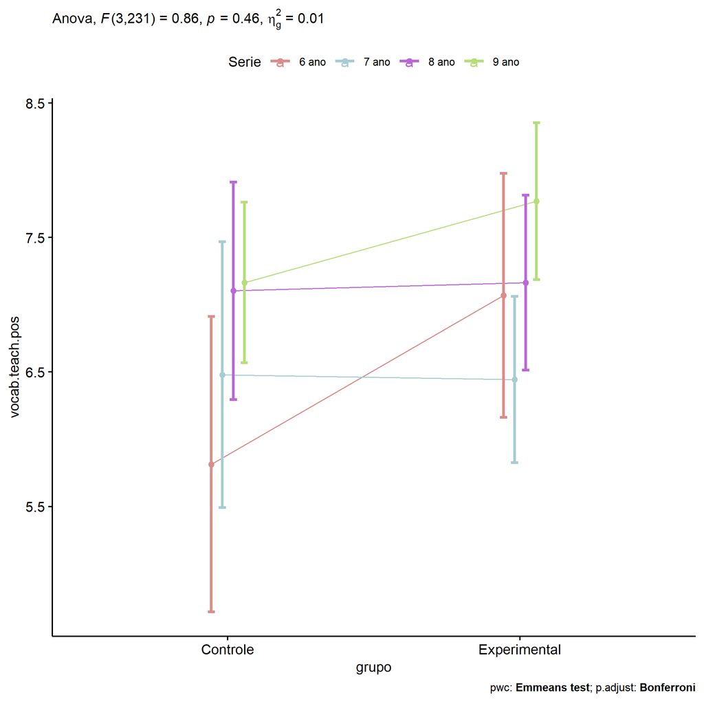

```r
if (!is.null(plots[["grupo"]]))
  plots[["grupo"]] + ggplot2::scale_color_manual(values = color[["Serie"]])
```

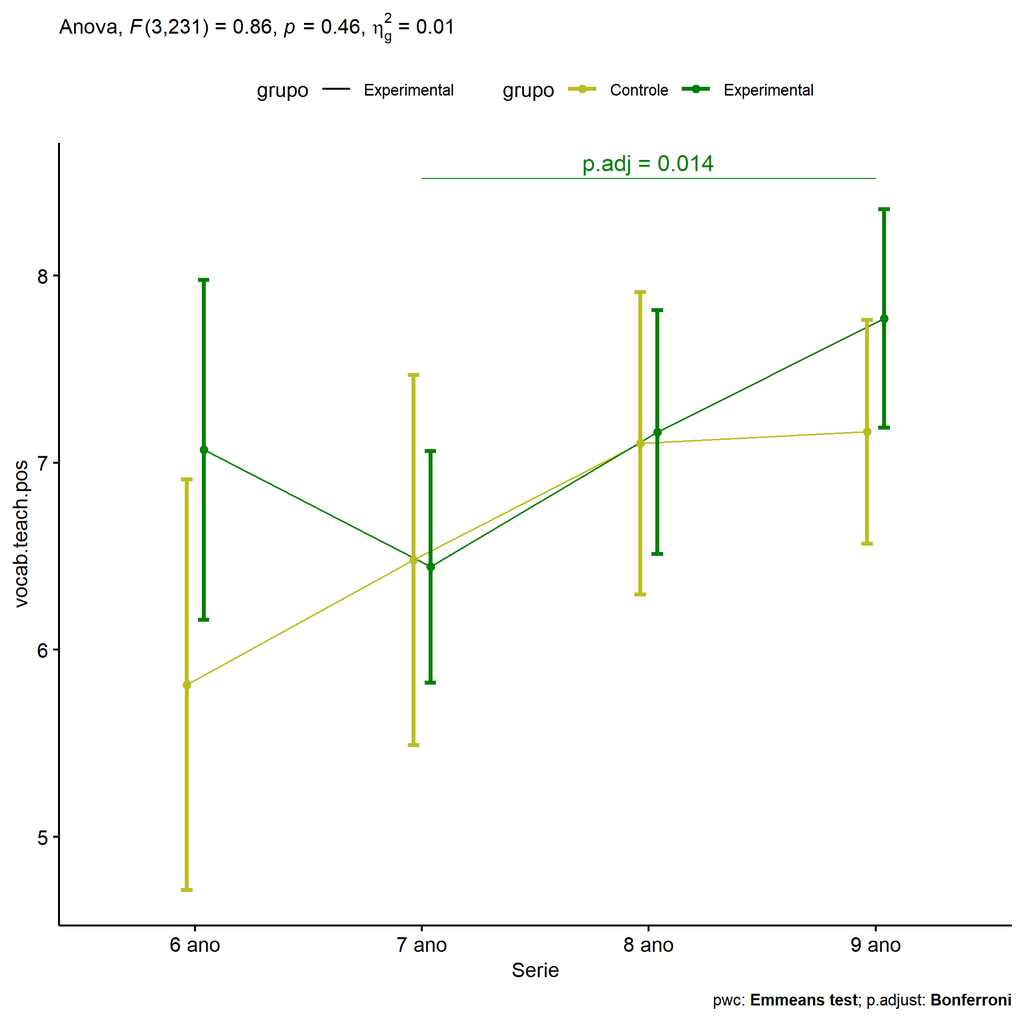

```r
if (!is.null(plots[["Serie"]]))
  plots[["Serie"]] + ggplot2::scale_color_manual(values = color[["grupo"]])
```

```r
plots <- twoWayAncovaBoxPlots(
  wdat, "vocab.teach.pos", c("grupo","Serie"), aov, pwcs, covar = "vocab.teach.pre",
  theme = "classic", color = color[["grupo:Serie"]],
  subtitle = which(aov$Effect == "grupo:Serie"))
```

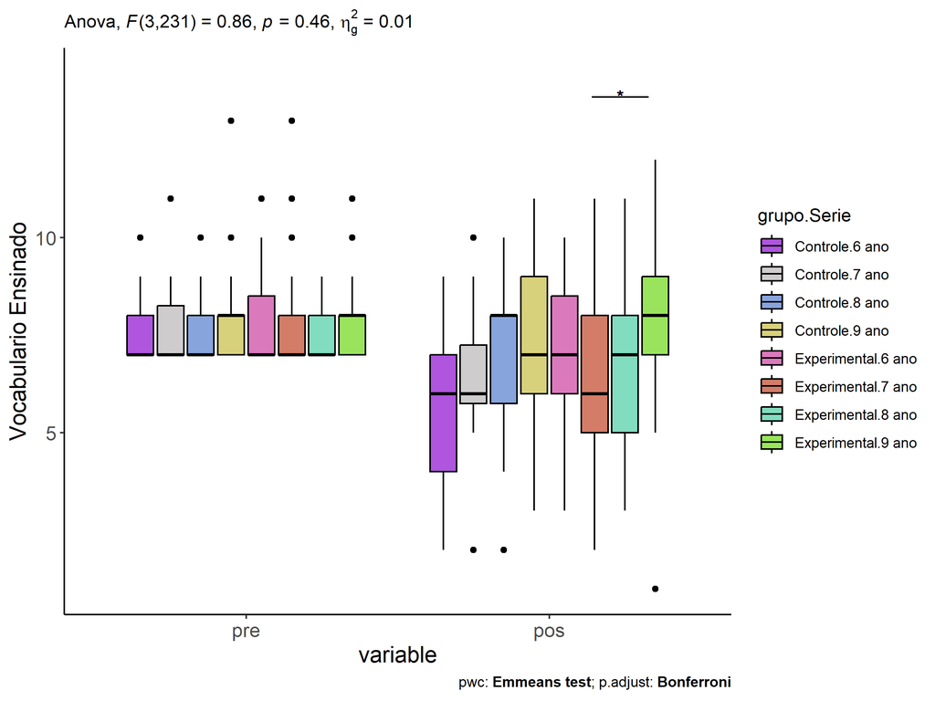

```r
plots[["grupo:Serie"]] + ggplot2::ylab("Vocabulario Ensinado") + ggplot2::scale_x_discrete(labels=c('pre', 'pos'))
```

```r
plots <- twoWayAncovaBoxPlots(
  wdat.long, "vocab.teach", c("grupo","Serie"), aov, pwc.long, pre.post = "time",
  theme = "classic", color = color$prepost)
```

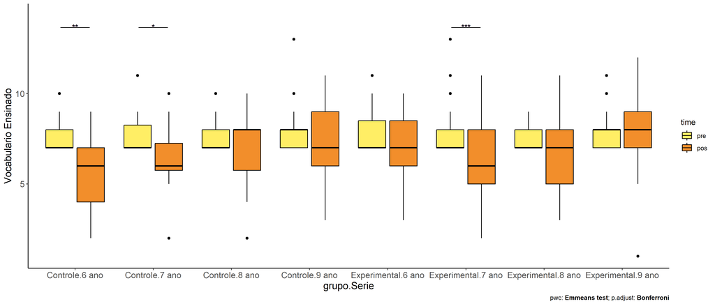

```r
plots[["grupo:Serie"]] + ggplot2::ylab("Vocabulario Ensinado")
```

### Checking linearity assumption

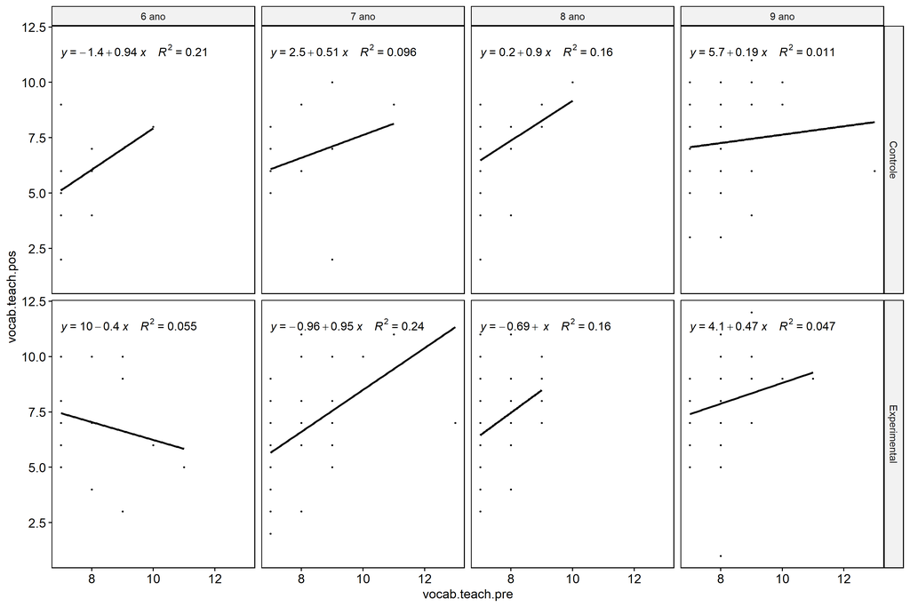

```r
ggscatter(wdat, x = "vocab.teach.pre", y = "vocab.teach.pos", size = 0.5,
          facet.by = c("grupo","Serie"), add = "reg.line")+
  stat_regline_equation(
    aes(label =  paste(..eq.label.., ..rr.label.., sep = "~~~~"))
  )
```

### Checking normality and homogeneity

```r
res <- augment(lm(vocab.teach.pos ~ vocab.teach.pre + grupo*Serie, data = wdat))
```

```r
shapiro_test(res$.resid)
```

```
## # A tibble: 1 × 3
##   variable   statistic p.value
##   <chr>          <dbl>   <dbl>
## 1 res$.resid     0.990  0.0848
```

```r
levene_test(res, .resid ~ grupo*Serie)
```

```
## # A tibble: 1 × 4
##     df1   df2 statistic     p
##   <int> <int>     <dbl> <dbl>
## 1     7   232      1.01 0.424
```

# Summary of Results

## Descriptive Statistics

```r
df <- get.descriptives(ldat[["grupo"]], c(dv.pre, dv.pos), c("grupo"),
                       include.global = T, symmetry.test = T, normality.test = F)
df <- plyr::rbind.fill(
  df, do.call(plyr::rbind.fill, lapply(lfatores2, FUN = function(f) {
    if (nrow(dat) > 0 && sum(!is.na(unique(dat[[f]]))) > 1)
      get.descriptives(ldat[[paste0("grupo:",f)]], c(dv.pre,dv.pos), c("grupo", f),
                       symmetry.test = T, normality.test = F)
    }))
)
(df <- df[,c(fatores1[fatores1 %in% colnames(df)],"variable",
             colnames(df)[!colnames(df) %in% c(fatores1,"variable")])])
```

```
##           grupo Sexo   Zona Cor.Raca Serie        variable  n  mean median min max    sd    se    ci
## 1      Controle <NA>   <NA>     <NA>  <NA> vocab.teach.pre 14 8.071    8.0   7  13 1.592 0.425 0.919
## 2  Experimental <NA>   <NA>     <NA>  <NA> vocab.teach.pre 29 7.862    7.0   7  13 1.432 0.266 0.545
## 3          <NA> <NA>   <NA>     <NA>  <NA> vocab.teach.pre 43 7.930    7.0   7  13 1.470 0.224 0.452
## 4      Controle <NA>   <NA>     <NA>  <NA> vocab.teach.pos 14 3.714    4.0   2   6 1.204 0.322 0.695
## 5  Experimental <NA>   <NA>     <NA>  <NA> vocab.teach.pos 29 4.276    4.0   2   7 1.131 0.210 0.430
## 6          <NA> <NA>   <NA>     <NA>  <NA> vocab.teach.pos 43 4.093    4.0   2   7 1.171 0.179 0.360
## 7      Controle    F   <NA>     <NA>  <NA> vocab.teach.pre 49 7.592    7.0   7  10 0.814 0.116 0.234
## 8      Controle    M   <NA>     <NA>  <NA> vocab.teach.pre 48 8.000    8.0   7  13 1.238 0.179 0.359
## 9  Experimental    F   <NA>     <NA>  <NA> vocab.teach.pre 72 7.833    7.5   7  13 1.126 0.133 0.265
## 10 Experimental    M   <NA>     <NA>  <NA> vocab.teach.pre 71 7.690    7.0   7  11 0.935 0.111 0.221
## 11     Controle    F   <NA>     <NA>  <NA> vocab.teach.pos 49 6.918    7.0   2  10 1.891 0.270 0.543
## 12     Controle    M   <NA>     <NA>  <NA> vocab.teach.pos 48 6.812    7.0   2  11 2.170 0.313 0.630
## 13 Experimental    F   <NA>     <NA>  <NA> vocab.teach.pos 72 7.514    8.0   2  11 2.076 0.245 0.488
## 14 Experimental    M   <NA>     <NA>  <NA> vocab.teach.pos 71 6.746    7.0   1  12 2.215 0.263 0.524
```

[output cut: 79 more lines]

| grupo | Sexo | Zona | Cor.Raca | Serie | variable | n | mean | median | min | max | sd | se | ci | iqr | symmetry | skewness | kurtosis |
| --- | --- | --- | --- | --- | --- | --- | --- | --- | --- | --- | --- | --- | --- | --- | --- | --- | --- |
| Controle |  |  |  |  | vocab.teach.pre | 14 | 8.071 | 8.0 | 7 | 13 | 1.592 | 0.425 | 0.919 | 1.00 | NO | 2.019 | 3.674 |
| Experimental |  |  |  |  | vocab.teach.pre | 29 | 7.862 | 7.0 | 7 | 13 | 1.432 | 0.266 | 0.545 | 1.00 | NO | 1.993 | 3.792 |
|  |  |  |  |  | vocab.teach.pre | 43 | 7.930 | 7.0 | 7 | 13 | 1.470 | 0.224 | 0.452 | 1.00 | NO | 2.093 | 4.227 |
| Controle |  |  |  |  | vocab.teach.pos | 14 | 3.714 | 4.0 | 2 | 6 | 1.204 | 0.322 | 0.695 | 1.00 | YES | 0.020 | -0.989 |
| Experimental |  |  |  |  | vocab.teach.pos | 29 | 4.276 | 4.0 | 2 | 7 | 1.131 | 0.210 | 0.430 | 2.00 | YES | 0.185 | -0.448 |
|  |  |  |  |  | vocab.teach.pos | 43 | 4.093 | 4.0 | 2 | 7 | 1.171 | 0.179 | 0.360 | 2.00 | YES | 0.085 | -0.421 |
| Controle | F |  |  |  | vocab.teach.pre | 49 | 7.592 | 7.0 | 7 | 10 | 0.814 | 0.116 | 0.234 | 1.00 | NO | 1.070 | 0.018 |
| Controle | M |  |  |  | vocab.teach.pre | 48 | 8.000 | 8.0 | 7 | 13 | 1.238 | 0.179 | 0.359 | 1.00 | NO | 1.780 | 3.924 |
| Experimental | F |  |  |  | vocab.teach.pre | 72 | 7.833 | 7.5 | 7 | 13 | 1.126 | 0.133 | 0.265 | 1.00 | NO | 1.901 | 4.910 |
| Experimental | M |  |  |  | vocab.teach.pre | 71 | 7.690 | 7.0 | 7 | 11 | 0.935 | 0.111 | 0.221 | 1.00 | NO | 1.465 | 2.189 |
| Controle | F |  |  |  | vocab.teach.pos | 49 | 6.918 | 7.0 | 2 | 10 | 1.891 | 0.270 | 0.543 | 2.00 | YES | -0.139 | -0.616 |
| Controle | M |  |  |  | vocab.teach.pos | 48 | 6.812 | 7.0 | 2 | 11 | 2.170 | 0.313 | 0.630 | 2.25 | YES | -0.290 | -0.533 |
| Experimental | F |  |  |  | vocab.teach.pos | 72 | 7.514 | 8.0 | 2 | 11 | 2.076 | 0.245 | 0.488 | 3.00 | YES | -0.392 | -0.402 |
| Experimental | M |  |  |  | vocab.teach.pos | 71 | 6.746 | 7.0 | 1 | 12 | 2.215 | 0.263 | 0.524 | 3.00 | YES | -0.134 | -0.422 |
| Controle |  | Rural |  |  | vocab.teach.pre | 46 | 7.630 | 7.0 | 7 | 11 | 0.951 | 0.140 | 0.282 | 1.00 | NO | 1.527 | 1.943 |
| Controle |  | Urbana |  |  | vocab.teach.pre | 18 | 7.611 | 7.0 | 7 | 10 | 0.979 | 0.231 | 0.487 | 1.00 | few data | 0.000 | 0.000 |
| Experimental |  | Rural |  |  | vocab.teach.pre | 61 | 7.689 | 7.0 | 7 | 11 | 0.975 | 0.125 | 0.250 | 1.00 | NO | 1.487 | 2.037 |
| Experimental |  | Urbana |  |  | vocab.teach.pre | 40 | 7.950 | 8.0 | 7 | 13 | 1.239 | 0.196 | 0.396 | 1.00 | NO | 2.062 | 5.208 |
| Controle |  | Rural |  |  | vocab.teach.pos | 46 | 7.043 | 7.0 | 2 | 10 | 2.022 | 0.298 | 0.600 | 2.75 | NO | -0.516 | -0.236 |
| Controle |  | Urbana |  |  | vocab.teach.pos | 18 | 6.611 | 6.0 | 5 | 10 | 1.501 | 0.354 | 0.746 | 1.00 | NO | 0.834 | -0.493 |
| Experimental |  | Rural |  |  | vocab.teach.pos | 61 | 7.295 | 7.0 | 3 | 12 | 2.246 | 0.288 | 0.575 | 4.00 | YES | -0.086 | -0.895 |
| Experimental |  | Urbana |  |  | vocab.teach.pos | 40 | 7.250 | 7.0 | 3 | 11 | 2.085 | 0.330 | 0.667 | 2.25 | YES | -0.325 | -0.446 |
| Controle |  |  | Branca |  | vocab.teach.pre | 9 | 8.000 | 7.0 | 7 | 11 | 1.414 | 0.471 | 1.087 | 2.00 | NO | 0.943 | -0.556 |
| Controle |  |  | Parda |  | vocab.teach.pre | 29 | 7.828 | 7.0 | 7 | 13 | 1.391 | 0.258 | 0.529 | 1.00 | NO | 1.990 | 4.161 |
| Experimental |  |  | Branca |  | vocab.teach.pre | 14 | 7.357 | 7.0 | 7 | 8 | 0.497 | 0.133 | 0.287 | 1.00 | few data | 0.000 | 0.000 |
| Experimental |  |  | Parda |  | vocab.teach.pre | 34 | 7.882 | 8.0 | 7 | 10 | 0.913 | 0.157 | 0.319 | 2.00 | YES | 0.454 | -1.172 |
| Controle |  |  | Branca |  | vocab.teach.pos | 9 | 7.222 | 8.0 | 4 | 11 | 2.333 | 0.778 | 1.794 | 4.00 | YES | 0.078 | -1.564 |
| Controle |  |  | Parda |  | vocab.teach.pos | 29 | 6.931 | 7.0 | 2 | 10 | 2.103 | 0.391 | 0.800 | 3.00 | YES | -0.246 | -0.642 |
| Experimental |  |  | Branca |  | vocab.teach.pos | 14 | 7.286 | 7.0 | 4 | 10 | 1.816 | 0.485 | 1.048 | 2.75 | YES | -0.037 | -1.170 |
| Experimental |  |  | Parda |  | vocab.teach.pos | 34 | 7.235 | 8.0 | 1 | 12 | 2.618 | 0.449 | 0.913 | 4.00 | YES | -0.318 | -0.678 |
| Controle |  |  |  | 6 ano | vocab.teach.pre | 13 | 7.692 | 7.0 | 7 | 10 | 0.947 | 0.263 | 0.572 | 1.00 | NO | 1.115 | 0.145 |
| Controle |  |  |  | 7 ano | vocab.teach.pre | 16 | 7.812 | 7.0 | 7 | 11 | 1.167 | 0.292 | 0.622 | 1.25 | NO | 1.281 | 0.808 |
| Controle |  |  |  | 8 ano | vocab.teach.pre | 24 | 7.583 | 7.0 | 7 | 10 | 0.881 | 0.180 | 0.372 | 1.00 | NO | 1.222 | 0.332 |
| Controle |  |  |  | 9 ano | vocab.teach.pre | 44 | 7.932 | 8.0 | 7 | 13 | 1.149 | 0.173 | 0.349 | 1.00 | NO | 2.106 | 6.351 |
| Experimental |  |  |  | 6 ano | vocab.teach.pre | 19 | 7.842 | 7.0 | 7 | 11 | 1.214 | 0.279 | 0.585 | 1.50 | NO | 1.166 | 0.200 |
| Experimental |  |  |  | 7 ano | vocab.teach.pre | 41 | 7.902 | 7.0 | 7 | 13 | 1.281 | 0.200 | 0.404 | 1.00 | NO | 1.919 | 4.350 |
| Experimental |  |  |  | 8 ano | vocab.teach.pre | 37 | 7.622 | 7.0 | 7 | 9 | 0.794 | 0.131 | 0.265 | 1.00 | few data | 0.000 | 0.000 |
| Experimental |  |  |  | 9 ano | vocab.teach.pre | 46 | 7.717 | 8.0 | 7 | 11 | 0.886 | 0.131 | 0.263 | 1.00 | NO | 1.500 | 2.645 |
| Controle |  |  |  | 6 ano | vocab.teach.pos | 13 | 5.769 | 6.0 | 2 | 9 | 1.922 | 0.533 | 1.161 | 3.00 | YES | -0.219 | -0.900 |
| Controle |  |  |  | 7 ano | vocab.teach.pos | 16 | 6.500 | 6.0 | 2 | 10 | 1.932 | 0.483 | 1.030 | 1.50 | YES | -0.208 | -0.045 |
| Controle |  |  |  | 8 ano | vocab.teach.pos | 24 | 7.000 | 8.0 | 2 | 10 | 1.978 | 0.404 | 0.835 | 2.25 | NO | -0.743 | -0.306 |
| Controle |  |  |  | 9 ano | vocab.teach.pos | 44 | 7.250 | 7.0 | 3 | 11 | 2.036 | 0.307 | 0.619 | 3.00 | YES | -0.090 | -0.916 |
| Experimental |  |  |  | 6 ano | vocab.teach.pos | 19 | 7.105 | 7.0 | 3 | 10 | 2.079 | 0.477 | 1.002 | 2.50 | YES | -0.097 | -0.983 |
| Experimental |  |  |  | 7 ano | vocab.teach.pos | 41 | 6.512 | 6.0 | 2 | 11 | 2.491 | 0.389 | 0.786 | 3.00 | YES | 0.085 | -1.088 |
| Experimental |  |  |  | 8 ano | vocab.teach.pos | 37 | 7.081 | 7.0 | 3 | 11 | 2.019 | 0.332 | 0.673 | 3.00 | YES | -0.029 | -0.814 |
| Experimental |  |  |  | 9 ano | vocab.teach.pos | 46 | 7.739 | 8.0 | 1 | 12 | 1.914 | 0.282 | 0.568 | 2.00 | NO | -0.751 | 1.729 |

## ANCOVA Table Comparison

```r
df <- do.call(plyr::rbind.fill, laov)
(df <- df[!duplicated(df$Effect),])
```

```
##             Effect DFn DFd      F        p p<.05      ges DFn' DFd'     F'       p' p<.05'     ges'
## 1            grupo   1  40  4.409 4.20e-02     * 0.099000    1  237  1.110 2.93e-01        0.005000
## 2  vocab.teach.pre   1  40 19.726 6.88e-05     * 0.330000    1  237 17.225 4.63e-05      * 0.068000
## 4       grupo:Sexo   1 235  0.475 4.91e-01       0.002000    1  235  0.475 4.91e-01        0.002000
## 5             Sexo   1 235  4.267 4.00e-02     * 0.018000    1  235  4.267 4.00e-02      * 0.018000
## 8       grupo:Zona   1 160  0.134 7.14e-01       0.000839    1  160  0.134 7.14e-01        0.000839
## 10            Zona   1 160  0.594 4.42e-01       0.004000    1  160  0.594 4.42e-01        0.004000
## 11        Cor.Raca   1  81  0.411 5.23e-01       0.005000    1   81  0.411 5.23e-01        0.005000
## 13  grupo:Cor.Raca   1  81  0.085 7.71e-01       0.001000    1   81  0.085 7.71e-01        0.001000
## 16     grupo:Serie   3 231  0.862 4.61e-01       0.011000    3  231  0.862 4.61e-01        0.011000
## 17           Serie   3 231  4.123 7.00e-03     * 0.051000    3  231  4.123 7.00e-03      * 0.051000
```

|  | Effect | DFn | DFd | F | p | p<.05 | ges | DFn’ | DFd’ | F’ | p’ | p<.05’ | ges’ |
| --- | --- | --- | --- | --- | --- | --- | --- | --- | --- | --- | --- | --- | --- |
| 1 | grupo | 1 | 40 | 4.409 | 0.042 | * | 0.099 | 1 | 237 | 1.110 | 0.293 |  | 0.005 |
| 2 | vocab.teach.pre | 1 | 40 | 19.726 | 0.000 | * | 0.330 | 1 | 237 | 17.225 | 0.000 | * | 0.068 |
| 4 | grupo:Sexo | 1 | 235 | 0.475 | 0.491 |  | 0.002 | 1 | 235 | 0.475 | 0.491 |  | 0.002 |
| 5 | Sexo | 1 | 235 | 4.267 | 0.040 | * | 0.018 | 1 | 235 | 4.267 | 0.040 | * | 0.018 |
| 8 | grupo:Zona | 1 | 160 | 0.134 | 0.714 |  | 0.001 | 1 | 160 | 0.134 | 0.714 |  | 0.001 |
| 10 | Zona | 1 | 160 | 0.594 | 0.442 |  | 0.004 | 1 | 160 | 0.594 | 0.442 |  | 0.004 |
| 11 | Cor.Raca | 1 | 81 | 0.411 | 0.523 |  | 0.005 | 1 | 81 | 0.411 | 0.523 |  | 0.005 |
| 13 | grupo:Cor.Raca | 1 | 81 | 0.085 | 0.771 |  | 0.001 | 1 | 81 | 0.085 | 0.771 |  | 0.001 |
| 16 | grupo:Serie | 3 | 231 | 0.862 | 0.461 |  | 0.011 | 3 | 231 | 0.862 | 0.461 |  | 0.011 |
| 17 | Serie | 3 | 231 | 4.123 | 0.007 | * | 0.051 | 3 | 231 | 4.123 | 0.007 | * | 0.051 |

## PairWise Table Comparison

```r
df <- do.call(plyr::rbind.fill, lpwc)
df <- df[,c(names(lfatores), names(df)[!names(df) %in% c(names(lfatores),"term",".y.")])]
```

| grupo | Sexo | Zona | Cor.Raca | Serie | group1 | group2 | df | statistic | p | p.adj | p.adj.signif | df’ | statistic’ | p’ | p.adj’ | p.adj.signif’ |
| --- | --- | --- | --- | --- | --- | --- | --- | --- | --- | --- | --- | --- | --- | --- | --- | --- |
| Controle |  |  |  |  | pre | pos | 82 | 8.668 | 0.000 | 0.000 | **** | 476 | 3.875 | 0.000 | 0.000 | *** |
| Experimental |  |  |  |  | pre | pos | 82 | 10.268 | 0.000 | 0.000 | **** | 476 | 3.192 | 0.002 | 0.002 | ** |
|  |  |  |  |  | Controle | Experimental | 40 | -2.100 | 0.042 | 0.042 | * | 237 | -1.054 | 0.293 | 0.293 | ns |
| Controle | F |  |  |  | pre | pos | 472 | 2.011 | 0.045 | 0.045 | * | 472 | 2.011 | 0.045 | 0.045 | * |
| Controle | M |  |  |  | pre | pos | 472 | 3.509 | 0.000 | 0.000 | *** | 472 | 3.509 | 0.000 | 0.000 | *** |
| Controle |  |  |  |  | F | M | 235 | 0.769 | 0.442 | 0.442 | ns | 235 | 0.769 | 0.442 | 0.442 | ns |
| Experimental | F |  |  |  | pre | pos | 472 | 1.156 | 0.248 | 0.248 | ns | 472 | 1.156 | 0.248 | 0.248 | ns |
| Experimental | M |  |  |  | pre | pos | 472 | 3.391 | 0.001 | 0.001 | *** | 472 | 3.391 | 0.001 | 0.001 | *** |
| Experimental |  |  |  |  | F | M | 235 | 2.032 | 0.043 | 0.043 | * | 235 | 2.032 | 0.043 | 0.043 | * |
|  | F |  |  |  | Controle | Experimental | 235 | -1.240 | 0.216 | 0.216 | ns | 235 | -1.240 | 0.216 | 0.216 | ns |
|  | M |  |  |  | Controle | Experimental | 235 | -0.253 | 0.800 | 0.800 | ns | 235 | -0.253 | 0.800 | 0.800 | ns |
| Controle |  |  |  |  | Rural | Urbana | 160 | 0.752 | 0.453 | 0.453 | ns | 160 | 0.752 | 0.453 | 0.453 | ns |
| Controle |  | Rural |  |  | pre | pos | 322 | 1.714 | 0.087 | 0.087 | ns | 322 | 1.714 | 0.087 | 0.087 | ns |
| Controle |  | Urbana |  |  | pre | pos | 322 | 1.827 | 0.069 | 0.069 | ns | 322 | 1.827 | 0.069 | 0.069 | ns |
| Experimental |  |  |  |  | Rural | Urbana | 160 | 0.403 | 0.687 | 0.687 | ns | 160 | 0.403 | 0.687 | 0.687 | ns |
| Experimental |  | Rural |  |  | pre | pos | 322 | 1.323 | 0.187 | 0.187 | ns | 322 | 1.323 | 0.187 | 0.187 | ns |
| Experimental |  | Urbana |  |  | pre | pos | 322 | 1.906 | 0.058 | 0.058 | ns | 322 | 1.906 | 0.058 | 0.058 | ns |
|  |  | Rural |  |  | Controle | Experimental | 160 | -0.567 | 0.571 | 0.571 | ns | 160 | -0.567 | 0.571 | 0.571 | ns |
|  |  | Urbana |  |  | Controle | Experimental | 160 | -0.833 | 0.406 | 0.406 | ns | 160 | -0.833 | 0.406 | 0.406 | ns |
| Controle |  |  | Branca |  | pre | pos | 164 | 0.912 | 0.363 | 0.363 | ns | 164 | 0.912 | 0.363 | 0.363 | ns |
| Controle |  |  |  |  | Branca | Parda | 81 | 0.188 | 0.851 | 0.851 | ns | 81 | 0.188 | 0.851 | 0.851 | ns |
| Controle |  |  | Parda |  | pre | pos | 164 | 1.886 | 0.061 | 0.061 | ns | 164 | 1.886 | 0.061 | 0.061 | ns |
| Experimental |  |  | Branca |  | pre | pos | 164 | 0.104 | 0.917 | 0.917 | ns | 164 | 0.104 | 0.917 | 0.917 | ns |
| Experimental |  |  |  |  | Branca | Parda | 81 | 0.678 | 0.500 | 0.500 | ns | 81 | 0.678 | 0.500 | 0.500 | ns |
| Experimental |  |  | Parda |  | pre | pos | 164 | 1.474 | 0.142 | 0.142 | ns | 164 | 1.474 | 0.142 | 0.142 | ns |
|  |  |  | Branca |  | Controle | Experimental | 81 | -0.620 | 0.537 | 0.537 | ns | 81 | -0.620 | 0.537 | 0.537 | ns |
|  |  |  | Parda |  | Controle | Experimental | 81 | -0.481 | 0.632 | 0.632 | ns | 81 | -0.481 | 0.632 | 0.632 | ns |
| Controle |  |  |  | 6 ano | pre | pos | 464 | 2.973 | 0.003 | 0.003 | ** | 464 | 2.973 | 0.003 | 0.003 | ** |
| Controle |  |  |  | 7 ano | pre | pos | 464 | 2.251 | 0.025 | 0.025 | * | 464 | 2.251 | 0.025 | 0.025 | * |
| Controle |  |  |  | 8 ano | pre | pos | 464 | 1.225 | 0.221 | 0.221 | ns | 464 | 1.225 | 0.221 | 0.221 | ns |
| Controle |  |  |  | 9 ano | pre | pos | 464 | 1.939 | 0.053 | 0.053 | ns | 464 | 1.939 | 0.053 | 0.053 | ns |
| Controle |  |  |  |  | 6 ano | 7 ano | 231 | -0.888 | 0.376 | 1.000 | ns | 231 | -0.888 | 0.376 | 1.000 | ns |
| Controle |  |  |  |  | 6 ano | 8 ano | 231 | -1.865 | 0.063 | 0.381 | ns | 231 | -1.865 | 0.063 | 0.381 | ns |
| Controle |  |  |  |  | 6 ano | 9 ano | 231 | -2.129 | 0.034 | 0.206 | ns | 231 | -2.129 | 0.034 | 0.206 | ns |
| Controle |  |  |  |  | 7 ano | 8 ano | 231 | -0.962 | 0.337 | 1.000 | ns | 231 | -0.962 | 0.337 | 1.000 | ns |
| Controle |  |  |  |  | 7 ano | 9 ano | 231 | -1.169 | 0.244 | 1.000 | ns | 231 | -1.169 | 0.244 | 1.000 | ns |
| Controle |  |  |  |  | 8 ano | 9 ano | 231 | -0.120 | 0.904 | 1.000 | ns | 231 | -0.120 | 0.904 | 1.000 | ns |
| Experimental |  |  |  | 6 ano | pre | pos | 464 | 1.377 | 0.169 | 0.169 | ns | 464 | 1.377 | 0.169 | 0.169 | ns |
| Experimental |  |  |  | 7 ano | pre | pos | 464 | 3.816 | 0.000 | 0.000 | *** | 464 | 3.816 | 0.000 | 0.000 | *** |
| Experimental |  |  |  | 8 ano | pre | pos | 464 | 1.410 | 0.159 | 0.159 | ns | 464 | 1.410 | 0.159 | 0.159 | ns |
| Experimental |  |  |  | 9 ano | pre | pos | 464 | -0.063 | 0.950 | 0.950 | ns | 464 | -0.063 | 0.950 | 0.950 | ns |
| Experimental |  |  |  |  | 6 ano | 7 ano | 231 | 1.123 | 0.263 | 1.000 | ns | 231 | 1.123 | 0.263 | 1.000 | ns |
| Experimental |  |  |  |  | 6 ano | 8 ano | 231 | -0.168 | 0.867 | 1.000 | ns | 231 | -0.168 | 0.867 | 1.000 | ns |
| Experimental |  |  |  |  | 6 ano | 9 ano | 231 | -1.280 | 0.202 | 1.000 | ns | 231 | -1.280 | 0.202 | 1.000 | ns |
| Experimental |  |  |  |  | 7 ano | 8 ano | 231 | -1.578 | 0.116 | 0.695 | ns | 231 | -1.578 | 0.116 | 0.695 | ns |
| Experimental |  |  |  |  | 7 ano | 9 ano | 231 | -3.073 | 0.002 | 0.014 | * | 231 | -3.073 | 0.002 | 0.014 | * |
| Experimental |  |  |  |  | 8 ano | 9 ano | 231 | -1.367 | 0.173 | 1.000 | ns | 231 | -1.367 | 0.173 | 1.000 | ns |
|  |  |  |  | 6 ano | Controle | Experimental | 231 | -1.736 | 0.084 | 0.084 | ns | 231 | -1.736 | 0.084 | 0.084 | ns |
|  |  |  |  | 7 ano | Controle | Experimental | 231 | 0.062 | 0.951 | 0.951 | ns | 231 | 0.062 | 0.951 | 0.951 | ns |
|  |  |  |  | 8 ano | Controle | Experimental | 231 | -0.115 | 0.909 | 0.909 | ns | 231 | -0.115 | 0.909 | 0.909 | ns |
|  |  |  |  | 9 ano | Controle | Experimental | 231 | -1.426 | 0.155 | 0.155 | ns | 231 | -1.426 | 0.155 | 0.155 | ns |

## EMMS Table Comparison

```r
df <- do.call(plyr::rbind.fill, lemms)
df[["N-N'"]] <- df[["N"]] - df[["N'"]]
df <- df[,c(names(lfatores), names(df)[!names(df) %in% names(lfatores)])]
```

| grupo | Sexo | Zona | Cor.Raca | Serie | N | M (pre) | SE (pre) | M (unadj) | SE (unadj) | M (adj) | SE (adj) | N’ | M (pre)’ | SE (pre)’ | M (unadj)’ | SE (unadj)’ | M (adj)’ | SE (adj)’ | N-N’ |
| --- | --- | --- | --- | --- | --- | --- | --- | --- | --- | --- | --- | --- | --- | --- | --- | --- | --- | --- | --- |
| Controle |  |  |  |  | 14 | 8.071 | 0.425 | 3.714 | 0.322 | 3.651 | 0.256 | 97 | 7.794 | 0.108 | 6.866 | 0.206 | 6.856 | 0.208 | -83 |
| Experimental |  |  |  |  | 29 | 7.862 | 0.266 | 4.276 | 0.210 | 4.306 | 0.178 | 143 | 7.762 | 0.086 | 7.133 | 0.182 | 7.140 | 0.171 | -114 |
| Controle | F |  |  |  | 49 | 7.592 | 0.116 | 6.918 | 0.270 | 7.015 | 0.291 | 49 | 7.592 | 0.116 | 6.918 | 0.270 | 7.015 | 0.291 | 0 |
| Controle | M |  |  |  | 48 | 8.000 | 0.179 | 6.812 | 0.313 | 6.694 | 0.295 | 48 | 8.000 | 0.179 | 6.812 | 0.313 | 6.694 | 0.295 | 0 |
| Experimental | F |  |  |  | 72 | 7.833 | 0.133 | 7.514 | 0.245 | 7.483 | 0.240 | 72 | 7.833 | 0.133 | 7.514 | 0.245 | 7.483 | 0.240 | 0 |
| Experimental | M |  |  |  | 71 | 7.690 | 0.111 | 6.746 | 0.263 | 6.791 | 0.242 | 71 | 7.690 | 0.111 | 6.746 | 0.263 | 6.791 | 0.242 | 0 |
| Controle |  | Rural |  |  | 46 | 7.630 | 0.140 | 7.043 | 0.298 | 7.089 | 0.299 | 46 | 7.630 | 0.140 | 7.043 | 0.298 | 7.089 | 0.299 | 0 |
| Controle |  | Urbana |  |  | 18 | 7.611 | 0.231 | 6.611 | 0.354 | 6.665 | 0.478 | 18 | 7.611 | 0.231 | 6.611 | 0.354 | 6.665 | 0.478 | 0 |
| Experimental |  | Rural |  |  | 61 | 7.689 | 0.125 | 7.295 | 0.288 | 7.313 | 0.259 | 61 | 7.689 | 0.125 | 7.295 | 0.288 | 7.313 | 0.259 | 0 |
| Experimental |  | Urbana |  |  | 40 | 7.950 | 0.196 | 7.250 | 0.330 | 7.146 | 0.322 | 40 | 7.950 | 0.196 | 7.250 | 0.330 | 7.146 | 0.322 | 0 |
| Controle |  |  | Branca |  | 9 | 8.000 | 0.471 | 7.222 | 0.778 | 7.056 | 0.716 | 9 | 8.000 | 0.471 | 7.222 | 0.778 | 7.056 | 0.716 | 0 |
| Controle |  |  | Parda |  | 29 | 7.828 | 0.258 | 6.931 | 0.391 | 6.902 | 0.398 | 29 | 7.828 | 0.258 | 6.931 | 0.391 | 6.902 | 0.398 | 0 |
| Experimental |  |  | Branca |  | 14 | 7.357 | 0.133 | 7.286 | 0.485 | 7.630 | 0.581 | 14 | 7.357 | 0.133 | 7.286 | 0.485 | 7.630 | 0.581 | 0 |
| Experimental |  |  | Parda |  | 34 | 7.882 | 0.157 | 7.235 | 0.449 | 7.162 | 0.368 | 34 | 7.882 | 0.157 | 7.235 | 0.449 | 7.162 | 0.368 | 0 |
| Controle |  |  |  | 6 ano | 13 | 7.692 | 0.263 | 5.769 | 0.533 | 5.814 | 0.557 | 13 | 7.692 | 0.263 | 5.769 | 0.533 | 5.814 | 0.557 | 0 |
| Controle |  |  |  | 7 ano | 16 | 7.812 | 0.292 | 6.500 | 0.483 | 6.480 | 0.502 | 16 | 7.812 | 0.292 | 6.500 | 0.483 | 6.480 | 0.502 | 0 |
| Controle |  |  |  | 8 ano | 24 | 7.583 | 0.180 | 7.000 | 0.404 | 7.104 | 0.411 | 24 | 7.583 | 0.180 | 7.000 | 0.404 | 7.104 | 0.411 | 0 |
| Controle |  |  |  | 9 ano | 44 | 7.932 | 0.173 | 7.250 | 0.307 | 7.165 | 0.303 | 44 | 7.932 | 0.173 | 7.250 | 0.307 | 7.165 | 0.303 | 0 |
| Experimental |  |  |  | 6 ano | 19 | 7.842 | 0.279 | 7.105 | 0.477 | 7.069 | 0.461 | 19 | 7.842 | 0.279 | 7.105 | 0.477 | 7.069 | 0.461 | 0 |
| Experimental |  |  |  | 7 ano | 41 | 7.902 | 0.200 | 6.512 | 0.389 | 6.443 | 0.314 | 41 | 7.902 | 0.200 | 6.512 | 0.389 | 6.443 | 0.314 | 0 |
| Experimental |  |  |  | 8 ano | 37 | 7.622 | 0.131 | 7.081 | 0.332 | 7.164 | 0.331 | 37 | 7.622 | 0.131 | 7.081 | 0.332 | 7.164 | 0.331 | 0 |
| Experimental |  |  |  | 9 ano | 46 | 7.717 | 0.131 | 7.739 | 0.282 | 7.770 | 0.296 | 46 | 7.717 | 0.131 | 7.739 | 0.282 | 7.770 | 0.296 | 0 |